# National Charitable Organisation Project

1. Import Libraries\ 2. Import Data\ 3. Data Description & Exploration

- Data Shape
- Columns & dtype
- Peek at the Data
- Missing Values %
- Statistics
- Correlations (numeric variables)
- Data Distributions (Histograms)

4. Data Preparation

- Dropped Columns
- Handle Missing Values
- Prepare Data for Scaling
- Scaling: StandardScaler()
- Scaling: RobustScaler()

5. About Algorithms

- Set-up the test harness to use 10-fold cross validation
- Build Models:
  - Logistic Regression (LR)
  - Linear Discriminant Analysis (LDA)
  - K-Nearest Neighbors (KNN)
  - Classification and Regression Trees (CART)
  - Random Forest Decision Tree (RFTree)
  - Gradient Boosting (GrB)
  - Gaussian Naive Bayes (NB)
  - Support Vector Machines (SVM)
  - Deep Learning (Deep)

6. Evaluate Some Algorithms

- 6.1.a Create a Validation Dataset with Standard Scaled Data
- 6.2.a Build Models, Make and Evaluate Predictions on different models with Standard Scaled Data
- 6.1.b Create a Validation Dataset with Robust Scaled Data
- 6.2.b Build Models, Make and Evaluate Predictions on different models with Robust Scaled Data
- 6.3 Choose the best model

7. Train the Final Machine Learning Model\ 8. Save the Load Final Machine Learning Model\ 9. Data Preparation of New Data\ 10. Make Predictions

# 1. Import Libraries

##### Versions of the Libraries

```python
# Python version
import sys
print('Python: {}'.format(sys.version))
# numpy
import numpy
print('numpy: {}'.format(numpy.__version__))
# pandas
import pandas
print('pandas: {}'.format(pandas.__version__))
# scipy
import scipy
print('scipy: {}'.format(scipy.__version__))
# matplotlib
import matplotlib
print('matplotlib: {}'.format(matplotlib.__version__))
# seaborn
import seaborn
print('seaborn: {}'.format(seaborn.__version__))
# scikit-learn
import sklearn
print('sklearn: {}'.format(sklearn.__version__))
# joblib
import joblib
print('joblib: {}'.format(joblib.__version__))
```

```
Python: 3.7.6 (default, Jan  8 2020, 20:23:39) [MSC v.1916 64 bit (AMD64)]
numpy: 1.18.1
pandas: 1.0.1
scipy: 1.4.1
matplotlib: 3.1.3
seaborn: 0.10.0
sklearn: 0.22.1
joblib: 0.14.1
```

- Python: 3.7.6 (default, Jan 8 2020, 20:23:39) [MSC v.1916 64 bit (AMD64)]
- numpy: 1.18.1
- pandas: 1.0.1
- scipy: 1.4.1
- matplotlib: 3.1.3
- seaborn: 0.10.0
- sklearn: 0.22.1
- joblib: 0.14.1

##### Import Libraries

```python
import numpy as np
import pandas as pd
from pandas import read_csv
from pandas.plotting import scatter_matrix
pd.set_option('display.max_columns', None) # Set it to None to display all columns in the dataframe
pd.set_option('display.width', None) # Width of the display in characters. If set to None and pandas will correctly auto-detect the width
pd.set_option('display.max_colwidth', None) # The maximum width in characters of a column in the repr of a pandas data structure
pd.options.mode.chained_assignment = None # switch off pandas warning
from scipy import stats  # library of statistical functions
import matplotlib.pyplot as plt
%matplotlib inline
#plt.rcParams['figure.figsize'] = (14,12) # to change the charts size
import seaborn as sns      # for drawing attractive and informative statistical graphics
import time
from sklearn import metrics
from sklearn import preprocessing
from sklearn.model_selection import train_test_split
from sklearn.model_selection import cross_val_score
from sklearn.model_selection import StratifiedKFold
from sklearn.metrics import classification_report
from sklearn.metrics import confusion_matrix
from sklearn.metrics import accuracy_score
from sklearn.linear_model import LogisticRegression
from sklearn.discriminant_analysis import LinearDiscriminantAnalysis
from sklearn.neighbors import KNeighborsClassifier
from sklearn.tree import DecisionTreeClassifier
from sklearn.ensemble import RandomForestClassifier
from sklearn.ensemble import GradientBoostingClassifier
from sklearn.naive_bayes import GaussianNB
from sklearn.svm import SVC
from sklearn.neural_network import MLPClassifier
import joblib
```

**Correlations conditional formatting**

```python
def correlations_conditional_formatting(value):
  """
  Colors elements in a dateframe
  green if positive and red if
  negative. Does not color NaN
  values.
  """

  if value < -0.9:
    color = 'red'
  elif value > 0.9:
    color = 'green'
  else:
    color = 'gainsboro'

  return 'color: %s' % color
```

**Table of Content**

# 2. Import Data

```python
donor_data = pd.read_csv('Donor Raw Data_ML with Python.csv')             # Historical Data
prospective_data=pd.read_csv('Prospective Donor_ML with Python.csv')      # New Contact List
```

**Table of Content**

# 3. Data Description & Exploration

##### Data shape

```python
print('Donor Shape (Historical Data) : ',donor_data.shape)                  # Historical Data
print('Prospective Shape (New Contact List) : ',prospective_data.shape)     # New Contact List
```

```
Donor Shape (Historical Data) :  (19372, 50)
Prospective Shape (New Contact List) :  (2148, 48)
```

##### Donor Columns and Data Types

```python
print()
print('|Column Name Donors            |Type    |','\n')
donor_data.dtypes
```

```
|Column Name Donors            |Type    |
```

```
TARGET_B                         int64
TARGET_D                       float64
CONTROL_NUMBER                   int64
MONTHS_SINCE_ORIGIN              int64
DONOR_AGE                      float64
IN_HOUSE                         int64
URBANICITY                      object
SES                             object
CLUSTER_CODE                    object
HOME_OWNER                      object
DONOR_GENDER                    object
INCOME_GROUP                   float64
PUBLISHED_PHONE                  int64
OVERLAY_SOURCE                  object
MOR_HIT_RATE                     int64
WEALTH_RATING                  float64
MEDIAN_HOME_VALUE                int64
MEDIAN_HOUSEHOLD_INCOME          int64
PCT_OWNER_OCCUPIED               int64
PER_CAPITA_INCOME                int64
PCT_ATTRIBUTE1                   int64
PCT_ATTRIBUTE2                   int64
PCT_ATTRIBUTE3                   int64
PCT_ATTRIBUTE4                   int64
PEP_STAR                         int64
RECENT_STAR_STATUS               int64
RECENCY_STATUS_96NK             object
FREQUENCY_STATUS_97NK            int64
RECENT_RESPONSE_PROP           float64
RECENT_AVG_GIFT_AMT            float64
RECENT_CARD_RESPONSE_PROP      float64
RECENT_AVG_CARD_GIFT_AMT       float64
RECENT_RESPONSE_COUNT            int64
RECENT_CARD_RESPONSE_COUNT       int64
MONTHS_SINCE_LAST_PROM_RESP    float64
LIFETIME_CARD_PROM               int64
LIFETIME_PROM                    int64
LIFETIME_GIFT_AMOUNT           float64
LIFETIME_GIFT_COUNT              int64
LIFETIME_AVG_GIFT_AMT          float64
LIFETIME_GIFT_RANGE            float64
LIFETIME_MAX_GIFT_AMT          float64
LIFETIME_MIN_GIFT_AMT          float64
LAST_GIFT_AMT                  float64
CARD_PROM_12                     int64
NUMBER_PROM_12                   int64
MONTHS_SINCE_LAST_GIFT           int64
MONTHS_SINCE_FIRST_GIFT          int64
FILE_AVG_GIFT                  float64
FILE_CARD_GIFT                   int64
dtype: object
```

##### Prospective Columns and Data Types

```python
print()
print('|Column Name Prospective       |Type    |','\n')
prospective_data.dtypes
```

```
|Column Name Prospective       |Type    |
```

```
CONTROL_NUMBER                   int64
MONTHS_SINCE_ORIGIN              int64
DONOR_AGE                      float64
IN_HOUSE                         int64
URBANICITY                      object
SES                             object
CLUSTER_CODE                    object
HOME_OWNER                      object
DONOR_GENDER                    object
INCOME_GROUP                   float64
PUBLISHED_PHONE                  int64
OVERLAY_SOURCE                  object
MOR_HIT_RATE                     int64
WEALTH_RATING                  float64
MEDIAN_HOME_VALUE                int64
MEDIAN_HOUSEHOLD_INCOME          int64
PCT_OWNER_OCCUPIED               int64
PER_CAPITA_INCOME                int64
PCT_ATTRIBUTE1                   int64
PCT_ATTRIBUTE2                   int64
PCT_ATTRIBUTE3                   int64
PCT_ATTRIBUTE4                   int64
PEP_STAR                         int64
RECENT_STAR_STATUS               int64
RECENCY_STATUS_96NK             object
FREQUENCY_STATUS_97NK            int64
RECENT_RESPONSE_PROP           float64
RECENT_AVG_GIFT_AMT            float64
RECENT_CARD_RESPONSE_PROP      float64
RECENT_AVG_CARD_GIFT_AMT       float64
RECENT_RESPONSE_COUNT            int64
RECENT_CARD_RESPONSE_COUNT       int64
MONTHS_SINCE_LAST_PROM_RESP    float64
LIFETIME_CARD_PROM               int64
LIFETIME_PROM                    int64
LIFETIME_GIFT_AMOUNT           float64
LIFETIME_GIFT_COUNT              int64
LIFETIME_AVG_GIFT_AMT          float64
LIFETIME_GIFT_RANGE            float64
LIFETIME_MAX_GIFT_AMT          float64
LIFETIME_MIN_GIFT_AMT          float64
LAST_GIFT_AMT                  float64
CARD_PROM_12                     int64
NUMBER_PROM_12                   int64
MONTHS_SINCE_LAST_GIFT           int64
MONTHS_SINCE_FIRST_GIFT          int64
FILE_AVG_GIFT                  float64
FILE_CARD_GIFT                   int64
dtype: object
```

##### Peek at the Data

```python
print('\n','Donor Raw Data_ML with Python.csv       HEAD')
donor_data.head()
```

```
 Donor Raw Data_ML with Python.csv       HEAD
```

|  | TARGET_B | TARGET_D | CONTROL_NUMBER | MONTHS_SINCE_ORIGIN | DONOR_AGE | IN_HOUSE | URBANICITY | SES | CLUSTER_CODE | HOME_OWNER | DONOR_GENDER | INCOME_GROUP | PUBLISHED_PHONE | OVERLAY_SOURCE | MOR_HIT_RATE | WEALTH_RATING | MEDIAN_HOME_VALUE | MEDIAN_HOUSEHOLD_INCOME | PCT_OWNER_OCCUPIED | PER_CAPITA_INCOME | PCT_ATTRIBUTE1 | PCT_ATTRIBUTE2 | PCT_ATTRIBUTE3 | PCT_ATTRIBUTE4 | PEP_STAR | RECENT_STAR_STATUS | RECENCY_STATUS_96NK | FREQUENCY_STATUS_97NK | RECENT_RESPONSE_PROP | … |
| --- | --- | --- | --- | --- | --- | --- | --- | --- | --- | --- | --- | --- | --- | --- | --- | --- | --- | --- | --- | --- | --- | --- | --- | --- | --- | --- | --- | --- | --- | --- |
| 0 | 0 | NaN | 5 | 101 | 87.0 | 0 | ? | ? | . | H | M | 2.0 | 0 | P | 0 | NaN | 554 | 294 | 76 | 11855 | 0 | 0 | 0 | 0 | 1 | 0 | A | 1 | 0.067 | … |
| 1 | 1 | 10.0 | 12 | 137 | 79.0 | 0 | R | 2 | 45 | H | M | 7.0 | 0 | P | 0 | 3.0 | 334 | 212 | 72 | 10385 | 0 | 41 | 21 | 31 | 1 | 1 | S | 2 | 0.235 | … |
| 2 | 0 | NaN | 37 | 113 | 75.0 | 0 | S | 1 | 11 | H | F | 5.0 | 0 | P | 0 | 9.0 | 2388 | 405 | 63 | 30855 | 0 | 25 | 26 | 57 | 1 | 1 | S | 3 | 0.409 | … |
| 3 | 0 | NaN | 38 | 92 | NaN | 0 | U | 2 | 04 | H | F | 6.0 | 1 | B | 0 | 4.0 | 1688 | 153 | 3 | 16342 | 0 | 25 | 32 | 42 | 1 | 0 | A | 3 | 0.474 | … |
| 4 | 0 | NaN | 41 | 101 | 74.0 | 0 | R | 2 | 49 | U | F | 2.0 | 1 | B | 8 | 5.0 | 514 | 328 | 90 | 12107 | 0 | 33 | 36 | 37 | 0 | 0 | A | 1 | 0.100 | … |

```python
print('\n','Donor Raw Data_ML with Python.csv       TAIL')
donor_data.tail()
```

```
 Donor Raw Data_ML with Python.csv       TAIL
```

|  | TARGET_B | TARGET_D | CONTROL_NUMBER | MONTHS_SINCE_ORIGIN | DONOR_AGE | IN_HOUSE | URBANICITY | SES | CLUSTER_CODE | HOME_OWNER | DONOR_GENDER | INCOME_GROUP | PUBLISHED_PHONE | OVERLAY_SOURCE | MOR_HIT_RATE | WEALTH_RATING | MEDIAN_HOME_VALUE | MEDIAN_HOUSEHOLD_INCOME | PCT_OWNER_OCCUPIED | PER_CAPITA_INCOME | PCT_ATTRIBUTE1 | PCT_ATTRIBUTE2 | PCT_ATTRIBUTE3 | PCT_ATTRIBUTE4 | PEP_STAR | RECENT_STAR_STATUS | RECENCY_STATUS_96NK | FREQUENCY_STATUS_97NK | RECENT_RESPONSE_PROP | … |
| --- | --- | --- | --- | --- | --- | --- | --- | --- | --- | --- | --- | --- | --- | --- | --- | --- | --- | --- | --- | --- | --- | --- | --- | --- | --- | --- | --- | --- | --- | --- |
| 19367 | 0 | NaN | 191687 | 89 | 66.0 | 1 | U | 1 | 03 | H | F | 4.0 | 1 | B | 241 | 7.0 | 1224 | 411 | 53 | 17457 | 1 | 24 | 34 | 41 | 0 | 0 | A | 2 | 0.154 | … |
| 19368 | 0 | NaN | 191710 | 137 | 77.0 | 1 | C | 1 | 24 | H | F | 5.0 | 1 | B | 240 | 7.0 | 778 | 388 | 67 | 18431 | 3 | 36 | 28 | 56 | 1 | 1 | S | 3 | 0.200 | … |
| 19369 | 0 | NaN | 191746 | 29 | NaN | 1 | S | 1 | 11 | U | M | 1.0 | 1 | P | 0 | NaN | 383 | 203 | 74 | 11971 | 0 | 41 | 20 | 58 | 0 | 0 | N | 1 | 0.000 | … |
| 19370 | 0 | NaN | 191775 | 129 | 78.0 | 1 | ? | ? | . | U | M | 6.0 | 1 | B | 0 | 9.0 | 1861 | 421 | 84 | 22294 | 0 | 0 | 0 | 0 | 1 | 14 | A | 1 | 0.053 | … |
| 19371 | 1 | 150.0 | 191779 | 29 | 70.0 | 0 | ? | ? | . | U | M | 5.0 | 1 | B | 2 | NaN | 1432 | 636 | 98 | 35544 | 0 | 62 | 13 | 61 | 0 | 0 | N | 1 | 0.100 | … |

```python
print('\n','Prospective Raw Data_ML with Python.csv       HEAD')
prospective_data.head()
```

```
 Prospective Raw Data_ML with Python.csv       HEAD
```

|  | CONTROL_NUMBER | MONTHS_SINCE_ORIGIN | DONOR_AGE | IN_HOUSE | URBANICITY | SES | CLUSTER_CODE | HOME_OWNER | DONOR_GENDER | INCOME_GROUP | PUBLISHED_PHONE | OVERLAY_SOURCE | MOR_HIT_RATE | WEALTH_RATING | MEDIAN_HOME_VALUE | MEDIAN_HOUSEHOLD_INCOME | PCT_OWNER_OCCUPIED | PER_CAPITA_INCOME | PCT_ATTRIBUTE1 | PCT_ATTRIBUTE2 | PCT_ATTRIBUTE3 | PCT_ATTRIBUTE4 | PEP_STAR | RECENT_STAR_STATUS | RECENCY_STATUS_96NK | FREQUENCY_STATUS_97NK | RECENT_RESPONSE_PROP | RECENT_AVG_GIFT_AMT | RECENT_CARD_RESPONSE_PROP | … |
| --- | --- | --- | --- | --- | --- | --- | --- | --- | --- | --- | --- | --- | --- | --- | --- | --- | --- | --- | --- | --- | --- | --- | --- | --- | --- | --- | --- | --- | --- | --- |
| 0 | 139 | 101 | NaN | 0 | R | 2 | 46 | U | F | NaN | 0 | N | 0 | NaN | 655 | 219 | 77 | 12671 | 0 | 46 | 24 | 53 | 0 | 0 | A | 1 | 0.071 | 21.00 | 0.000 | … |
| 1 | 142 | 137 | NaN | 0 | R | 2 | 43 | U | F | NaN | 1 | N | 0 | 1.0 | 475 | 227 | 70 | 10221 | 0 | 30 | 33 | 29 | 1 | 1 | S | 2 | 0.350 | 10.00 | 0.500 | … |
| 2 | 282 | 17 | 30.0 | 0 | T | 1 | 35 | H | M | 6.0 | 1 | B | 11 | NaN | 1117 | 544 | 87 | 18212 | 1 | 27 | 70 | 21 | 0 | 0 | F | 1 | 0.077 | 20.00 | 0.200 | … |
| 3 | 368 | 137 | 75.0 | 0 | U | 1 | 02 | H | M | 6.0 | 1 | B | 1 | 7.0 | 2257 | 485 | 84 | 17885 | 0 | 43 | 28 | 41 | 1 | 10 | A | 1 | 0.333 | 8.83 | 0.444 | … |
| 4 | 387 | 5 | NaN | 0 | T | 2 | 40 | U | F | 2.0 | 0 | B | 0 | NaN | 789 | 413 | 97 | 14123 | 0 | 31 | 16 | 7 | 0 | 0 | A | 3 | 0.278 | 5.40 | 0.222 | … |

Donor Raw Data_ML with Python **(Historical Data)** and Prospective Donor_ML with Python **(New Contact List)** have practically the same structure.

In Prospective Donor_ML with Python **(New Contact List)** are missing two columns:

- TARGET_B: which it will be created and named "Prediction" and populated with the model predictions
- TARGET_D: which it will be dropped also in the historical data

##### Missing Values

```python
# missing value counts in each of these columns
miss = donor_data.isnull().sum()/len(donor_data)
miss = miss[miss > 0]
miss.sort_values(ascending=False,inplace=True)
# miss
# convert 'miss' from Series to DataFrame
miss_DF= miss.to_frame()
miss_DF
```

|  | 0 |
| --- | --- |
| TARGET_D | 0.750000 |
| WEALTH_RATING | 0.454780 |
| DONOR_AGE | 0.247522 |
| INCOME_GROUP | 0.226719 |
| MONTHS_SINCE_LAST_PROM_RESP | 0.012699 |

```python
#count of missing values
print('|Column Name Donor            |Type    |','\n')
donor_data.isna().sum()
```

```
|Column Name Donor            |Type    |
```

```
TARGET_B                           0
TARGET_D                       14529
CONTROL_NUMBER                     0
MONTHS_SINCE_ORIGIN                0
DONOR_AGE                       4795
IN_HOUSE                           0
URBANICITY                         0
SES                                0
CLUSTER_CODE                       0
HOME_OWNER                         0
DONOR_GENDER                       0
INCOME_GROUP                    4392
PUBLISHED_PHONE                    0
OVERLAY_SOURCE                     0
MOR_HIT_RATE                       0
WEALTH_RATING                   8810
MEDIAN_HOME_VALUE                  0
MEDIAN_HOUSEHOLD_INCOME            0
PCT_OWNER_OCCUPIED                 0
PER_CAPITA_INCOME                  0
PCT_ATTRIBUTE1                     0
PCT_ATTRIBUTE2                     0
PCT_ATTRIBUTE3                     0
PCT_ATTRIBUTE4                     0
PEP_STAR                           0
RECENT_STAR_STATUS                 0
RECENCY_STATUS_96NK                0
FREQUENCY_STATUS_97NK              0
RECENT_RESPONSE_PROP               0
RECENT_AVG_GIFT_AMT                0
RECENT_CARD_RESPONSE_PROP          0
RECENT_AVG_CARD_GIFT_AMT           0
RECENT_RESPONSE_COUNT              0
RECENT_CARD_RESPONSE_COUNT         0
MONTHS_SINCE_LAST_PROM_RESP      246
LIFETIME_CARD_PROM                 0
LIFETIME_PROM                      0
LIFETIME_GIFT_AMOUNT               0
LIFETIME_GIFT_COUNT                0
LIFETIME_AVG_GIFT_AMT              0
LIFETIME_GIFT_RANGE                0
LIFETIME_MAX_GIFT_AMT              0
LIFETIME_MIN_GIFT_AMT              0
LAST_GIFT_AMT                      0
CARD_PROM_12                       0
NUMBER_PROM_12                     0
MONTHS_SINCE_LAST_GIFT             0
MONTHS_SINCE_FIRST_GIFT            0
FILE_AVG_GIFT                      0
FILE_CARD_GIFT                     0
dtype: int64
```

```python
print('|Column Name Prospective      |Type    |','\n')
prospective_data.isna().sum()
```

```
|Column Name Prospective      |Type    |
```

```
CONTROL_NUMBER                    0
MONTHS_SINCE_ORIGIN               0
DONOR_AGE                       529
IN_HOUSE                          0
URBANICITY                        0
SES                               0
CLUSTER_CODE                      0
HOME_OWNER                        0
DONOR_GENDER                      0
INCOME_GROUP                    481
PUBLISHED_PHONE                   0
OVERLAY_SOURCE                    0
MOR_HIT_RATE                      0
WEALTH_RATING                  1006
MEDIAN_HOME_VALUE                 0
MEDIAN_HOUSEHOLD_INCOME           0
PCT_OWNER_OCCUPIED                0
PER_CAPITA_INCOME                 0
PCT_ATTRIBUTE1                    0
PCT_ATTRIBUTE2                    0
PCT_ATTRIBUTE3                    0
PCT_ATTRIBUTE4                    0
PEP_STAR                          0
RECENT_STAR_STATUS                0
RECENCY_STATUS_96NK               0
FREQUENCY_STATUS_97NK             0
RECENT_RESPONSE_PROP              0
RECENT_AVG_GIFT_AMT               0
RECENT_CARD_RESPONSE_PROP         0
RECENT_AVG_CARD_GIFT_AMT          0
RECENT_RESPONSE_COUNT             0
RECENT_CARD_RESPONSE_COUNT        0
MONTHS_SINCE_LAST_PROM_RESP      26
LIFETIME_CARD_PROM                0
LIFETIME_PROM                     0
LIFETIME_GIFT_AMOUNT              0
LIFETIME_GIFT_COUNT               0
LIFETIME_AVG_GIFT_AMT             0
LIFETIME_GIFT_RANGE               0
LIFETIME_MAX_GIFT_AMT             0
LIFETIME_MIN_GIFT_AMT             0
LAST_GIFT_AMT                     0
CARD_PROM_12                      0
NUMBER_PROM_12                    0
MONTHS_SINCE_LAST_GIFT            0
MONTHS_SINCE_FIRST_GIFT           0
FILE_AVG_GIFT                     0
FILE_CARD_GIFT                    0
dtype: int64
```

##### Statistics

```python
# statistics

donor_statistics = donor_data.describe()
```

```python
donor_statistics
```

|  | TARGET_B | TARGET_D | CONTROL_NUMBER | MONTHS_SINCE_ORIGIN | DONOR_AGE | IN_HOUSE | INCOME_GROUP | PUBLISHED_PHONE | MOR_HIT_RATE | WEALTH_RATING | MEDIAN_HOME_VALUE | MEDIAN_HOUSEHOLD_INCOME | PCT_OWNER_OCCUPIED | PER_CAPITA_INCOME | PCT_ATTRIBUTE1 | PCT_ATTRIBUTE2 | PCT_ATTRIBUTE3 | PCT_ATTRIBUTE4 | PEP_STAR | RECENT_STAR_STATUS | FREQUENCY_STATUS_97NK | RECENT_RESPONSE_PROP | RECENT_AVG_GIFT_AMT | RECENT_CARD_RESPONSE_PROP | RECENT_AVG_CARD_GIFT_AMT | RECENT_RESPONSE_COUNT | RECENT_CARD_RESPONSE_COUNT | MONTHS_SINCE_LAST_PROM_RESP | LIFETIME_CARD_PROM | … |
| --- | --- | --- | --- | --- | --- | --- | --- | --- | --- | --- | --- | --- | --- | --- | --- | --- | --- | --- | --- | --- | --- | --- | --- | --- | --- | --- | --- | --- | --- | --- |
| count | 19372.000000 | 4843.000000 | 19372.000000 | 19372.000000 | 14577.000000 | 19372.000000 | 14980.000000 | 19372.000000 | 19372.000000 | 10562.000000 | 19372.000000 | 19372.000000 | 19372.000000 | 19372.000000 | 19372.000000 | 19372.000000 | 19372.000000 | 19372.000000 | 19372.000000 | 19372.000000 | 19372.000000 | 19372.000000 | 19372.000000 | 19372.000000 | 19372.00000 | 19372.000000 | 19372.000000 | 19126.000000 | 19372.000000 | … |
| mean | 0.250000 | 15.624344 | 96546.225377 | 73.409973 | 58.919051 | 0.073198 | 3.907543 | 0.497729 | 3.361656 | 5.005397 | 1079.871929 | 341.970215 | 69.698999 | 15857.334452 | 1.029011 | 30.573921 | 29.603293 | 32.852467 | 0.504439 | 0.931138 | 1.983998 | 0.190127 | 15.365396 | 0.230808 | 11.68547 | 3.043103 | 1.730539 | 19.038900 | 18.668078 | … |
| std | 0.433024 | 12.445137 | 55830.643871 | 41.255574 | 16.669382 | 0.260469 | 1.864796 | 0.500008 | 9.503481 | 2.815386 | 960.753448 | 164.207807 | 21.711019 | 8710.630390 | 4.918297 | 11.421471 | 15.120360 | 17.839765 | 0.499993 | 2.545585 | 1.099346 | 0.113947 | 10.167485 | 0.186230 | 10.83412 | 2.046401 | 1.535521 | 3.415559 | 8.558778 | … |
| min | 0.000000 | 1.000000 | 5.000000 | 5.000000 | 0.000000 | 0.000000 | 1.000000 | 0.000000 | 0.000000 | 0.000000 | 0.000000 | 0.000000 | 0.000000 | 0.000000 | 0.000000 | 0.000000 | 0.000000 | 0.000000 | 0.000000 | 0.000000 | 1.000000 | 0.000000 | 0.000000 | 0.000000 | 0.00000 | 0.000000 | 0.000000 | -12.000000 | 2.000000 | … |
| 25% | 0.000000 | 10.000000 | 48289.000000 | 29.000000 | 47.000000 | 0.000000 | 2.000000 | 0.000000 | 0.000000 | 3.000000 | 518.000000 | 232.000000 | 60.000000 | 10869.000000 | 0.000000 | 25.000000 | 20.000000 | 21.000000 | 0.000000 | 0.000000 | 1.000000 | 0.105000 | 10.000000 | 0.100000 | 5.00000 | 2.000000 | 1.000000 | 17.000000 | 11.000000 | … |
| 50% | 0.000000 | 13.000000 | 96937.000000 | 65.000000 | 60.000000 | 0.000000 | 4.000000 | 0.000000 | 0.000000 | 5.000000 | 747.000000 | 311.000000 | 76.000000 | 13816.500000 | 0.000000 | 31.000000 | 29.000000 | 32.000000 | 1.000000 | 0.000000 | 2.000000 | 0.167000 | 14.000000 | 0.200000 | 10.14000 | 3.000000 | 1.000000 | 18.000000 | 18.000000 | … |
| 75% | 0.250000 | 20.000000 | 145429.500000 | 113.000000 | 73.000000 | 0.000000 | 5.000000 | 1.000000 | 3.000000 | 7.000000 | 1227.000000 | 417.000000 | 85.000000 | 18308.250000 | 0.000000 | 37.000000 | 39.000000 | 43.000000 | 1.000000 | 1.000000 | 3.000000 | 0.250000 | 20.000000 | 0.333000 | 16.00000 | 4.000000 | 2.000000 | 21.000000 | 26.000000 | … |
| max | 1.000000 | 200.000000 | 191779.000000 | 137.000000 | 87.000000 | 1.000000 | 7.000000 | 1.000000 | 241.000000 | 9.000000 | 6000.000000 | 1500.000000 | 99.000000 | 174523.000000 | 97.000000 | 99.000000 | 99.000000 | 99.000000 | 1.000000 | 22.000000 | 4.000000 | 1.000000 | 260.000000 | 1.000000 | 300.00000 | 16.000000 | 9.000000 | 36.000000 | 56.000000 | … |

```python
donor_statistics.to_csv('donor_statistics.csv')
```

```python
donor_statistics_transposed = donor_statistics.transpose()
```

```python
donor_statistics_transposed
```

|  | count | mean | std | min | 25% | 50% | 75% | max |
| --- | --- | --- | --- | --- | --- | --- | --- | --- |
| TARGET_B | 19372.0 | 0.250000 | 0.433024 | 0.00 | 0.000 | 0.000 | 0.250 | 1.0 |
| TARGET_D | 4843.0 | 15.624344 | 12.445137 | 1.00 | 10.000 | 13.000 | 20.000 | 200.0 |
| CONTROL_NUMBER | 19372.0 | 96546.225377 | 55830.643871 | 5.00 | 48289.000 | 96937.000 | 145429.500 | 191779.0 |
| MONTHS_SINCE_ORIGIN | 19372.0 | 73.409973 | 41.255574 | 5.00 | 29.000 | 65.000 | 113.000 | 137.0 |
| DONOR_AGE | 14577.0 | 58.919051 | 16.669382 | 0.00 | 47.000 | 60.000 | 73.000 | 87.0 |
| IN_HOUSE | 19372.0 | 0.073198 | 0.260469 | 0.00 | 0.000 | 0.000 | 0.000 | 1.0 |
| INCOME_GROUP | 14980.0 | 3.907543 | 1.864796 | 1.00 | 2.000 | 4.000 | 5.000 | 7.0 |
| PUBLISHED_PHONE | 19372.0 | 0.497729 | 0.500008 | 0.00 | 0.000 | 0.000 | 1.000 | 1.0 |
| MOR_HIT_RATE | 19372.0 | 3.361656 | 9.503481 | 0.00 | 0.000 | 0.000 | 3.000 | 241.0 |
| WEALTH_RATING | 10562.0 | 5.005397 | 2.815386 | 0.00 | 3.000 | 5.000 | 7.000 | 9.0 |
| MEDIAN_HOME_VALUE | 19372.0 | 1079.871929 | 960.753448 | 0.00 | 518.000 | 747.000 | 1227.000 | 6000.0 |
| MEDIAN_HOUSEHOLD_INCOME | 19372.0 | 341.970215 | 164.207807 | 0.00 | 232.000 | 311.000 | 417.000 | 1500.0 |
| PCT_OWNER_OCCUPIED | 19372.0 | 69.698999 | 21.711019 | 0.00 | 60.000 | 76.000 | 85.000 | 99.0 |
| PER_CAPITA_INCOME | 19372.0 | 15857.334452 | 8710.630390 | 0.00 | 10869.000 | 13816.500 | 18308.250 | 174523.0 |
| PCT_ATTRIBUTE1 | 19372.0 | 1.029011 | 4.918297 | 0.00 | 0.000 | 0.000 | 0.000 | 97.0 |
| PCT_ATTRIBUTE2 | 19372.0 | 30.573921 | 11.421471 | 0.00 | 25.000 | 31.000 | 37.000 | 99.0 |
| PCT_ATTRIBUTE3 | 19372.0 | 29.603293 | 15.120360 | 0.00 | 20.000 | 29.000 | 39.000 | 99.0 |
| PCT_ATTRIBUTE4 | 19372.0 | 32.852467 | 17.839765 | 0.00 | 21.000 | 32.000 | 43.000 | 99.0 |
| PEP_STAR | 19372.0 | 0.504439 | 0.499993 | 0.00 | 0.000 | 1.000 | 1.000 | 1.0 |
| RECENT_STAR_STATUS | 19372.0 | 0.931138 | 2.545585 | 0.00 | 0.000 | 0.000 | 1.000 | 22.0 |
| FREQUENCY_STATUS_97NK | 19372.0 | 1.983998 | 1.099346 | 1.00 | 1.000 | 2.000 | 3.000 | 4.0 |
| RECENT_RESPONSE_PROP | 19372.0 | 0.190127 | 0.113947 | 0.00 | 0.105 | 0.167 | 0.250 | 1.0 |
| RECENT_AVG_GIFT_AMT | 19372.0 | 15.365396 | 10.167485 | 0.00 | 10.000 | 14.000 | 20.000 | 260.0 |
| RECENT_CARD_RESPONSE_PROP | 19372.0 | 0.230808 | 0.186230 | 0.00 | 0.100 | 0.200 | 0.333 | 1.0 |
| RECENT_AVG_CARD_GIFT_AMT | 19372.0 | 11.685470 | 10.834120 | 0.00 | 5.000 | 10.140 | 16.000 | 300.0 |
| RECENT_RESPONSE_COUNT | 19372.0 | 3.043103 | 2.046401 | 0.00 | 2.000 | 3.000 | 4.000 | 16.0 |
| RECENT_CARD_RESPONSE_COUNT | 19372.0 | 1.730539 | 1.535521 | 0.00 | 1.000 | 1.000 | 2.000 | 9.0 |
| MONTHS_SINCE_LAST_PROM_RESP | 19126.0 | 19.038900 | 3.415559 | -12.00 | 17.000 | 18.000 | 21.000 | 36.0 |
| LIFETIME_CARD_PROM | 19372.0 | 18.668078 | 8.558778 | 2.00 | 11.000 | 18.000 | 26.000 | 56.0 |
| LIFETIME_PROM | 19372.0 | 47.570514 | 22.950158 | 5.00 | 28.000 | 47.000 | 64.000 | 194.0 |
| LIFETIME_GIFT_AMOUNT | 19372.0 | 104.425716 | 105.722460 | 15.00 | 42.000 | 79.000 | 132.000 | 3775.0 |
| LIFETIME_GIFT_COUNT | 19372.0 | 9.979765 | 8.688163 | 1.00 | 4.000 | 8.000 | 14.000 | 95.0 |
| LIFETIME_AVG_GIFT_AMT | 19372.0 | 12.858338 | 8.787758 | 1.36 | 8.000 | 11.200 | 15.000 | 450.0 |
| LIFETIME_GIFT_RANGE | 19372.0 | 11.587876 | 15.116893 | 0.00 | 5.000 | 10.000 | 15.000 | 997.0 |
| LIFETIME_MAX_GIFT_AMT | 19372.0 | 19.208808 | 16.101128 | 5.00 | 12.000 | 16.000 | 21.000 | 1000.0 |
| LIFETIME_MIN_GIFT_AMT | 19372.0 | 7.620932 | 7.959786 | 0.00 | 3.000 | 5.000 | 10.000 | 450.0 |
| LAST_GIFT_AMT | 19372.0 | 16.584199 | 11.977558 | 0.00 | 10.000 | 15.000 | 20.000 | 450.0 |
| CARD_PROM_12 | 19372.0 | 5.367128 | 1.264205 | 0.00 | 5.000 | 6.000 | 6.000 | 17.0 |
| NUMBER_PROM_12 | 19372.0 | 12.901869 | 4.642072 | 2.00 | 11.000 | 12.000 | 13.000 | 64.0 |
| MONTHS_SINCE_LAST_GIFT | 19372.0 | 18.191152 | 4.033065 | 4.00 | 16.000 | 18.000 | 20.000 | 27.0 |
| MONTHS_SINCE_FIRST_GIFT | 19372.0 | 69.482088 | 37.568169 | 15.00 | 33.000 | 65.000 | 105.000 | 260.0 |
| FILE_AVG_GIFT | 19372.0 | 12.858338 | 8.787758 | 1.36 | 8.000 | 11.200 | 15.000 | 450.0 |
| FILE_CARD_GIFT | 19372.0 | 5.273591 | 4.607063 | 0.00 | 2.000 | 4.000 | 8.000 | 41.0 |

```python
donor_statistics_transposed.to_csv('donor_statistics_transposed.csv')
```

```python
#skewness
print ("The skewness of TARGET_B is {:.2f}".format(donor_data['TARGET_B'].skew()))
```

```
The skewness of TARGET_B is 1.15
```

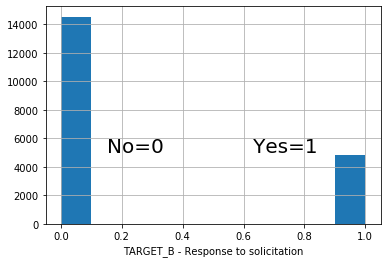

```python
donor_data['TARGET_B'].hist()
plt.xlabel('TARGET_B - Response to solicitation')
plt.text(0.15, 5000, 'No=0              Yes=1',dict(size=20))
plt.show()
```

##### separate variables into numeric and categorical data

```python
#numeric data
numeric_data = donor_data.select_dtypes(include=[np.number])

#categorical data
cat_data = donor_data.select_dtypes(exclude=[np.number])

print ("There are {} numeric and {} categorical columns in donor data (historical data).".
       format(numeric_data.shape[1],cat_data.shape[1]))
```

```
There are 43 numeric and 7 categorical columns in donor data (historical data).
```

##### correlations before Data Preparation

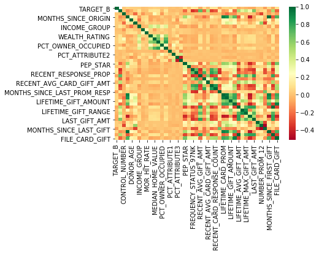

```python
#correlation plot
corr_before_Data_Preparation = numeric_data.corr()
sns.heatmap(corr_before_Data_Preparation, cmap='RdYlGn')
```

```python
corr_before_Data_Preparation.style.applymap(correlations_conditional_formatting)
```

|  | TARGET_B | TARGET_D | CONTROL_NUMBER | MONTHS_SINCE_ORIGIN | DONOR_AGE | IN_HOUSE | INCOME_GROUP | PUBLISHED_PHONE | MOR_HIT_RATE | WEALTH_RATING | MEDIAN_HOME_VALUE | MEDIAN_HOUSEHOLD_INCOME | PCT_OWNER_OCCUPIED | PER_CAPITA_INCOME | PCT_ATTRIBUTE1 | PCT_ATTRIBUTE2 | PCT_ATTRIBUTE3 | PCT_ATTRIBUTE4 | PEP_STAR | RECENT_STAR_STATUS | FREQUENCY_STATUS_97NK | RECENT_RESPONSE_PROP | RECENT_AVG_GIFT_AMT | RECENT_CARD_RESPONSE_PROP | RECENT_AVG_CARD_GIFT_AMT | RECENT_RESPONSE_COUNT | RECENT_CARD_RESPONSE_COUNT | MONTHS_SINCE_LAST_PROM_RESP | LIFETIME_CARD_PROM | … |
| --- | --- | --- | --- | --- | --- | --- | --- | --- | --- | --- | --- | --- | --- | --- | --- | --- | --- | --- | --- | --- | --- | --- | --- | --- | --- | --- | --- | --- | --- | --- |
| TARGET_B | 1.000000 | nan | 0.024607 | 0.062795 | 0.036949 | 0.040964 | 0.039932 | -0.003219 | 0.012689 | 0.034742 | 0.050377 | 0.038190 | 0.015720 | 0.041528 | -0.003648 | 0.008815 | -0.010106 | 0.010067 | 0.105389 | -0.001475 | 0.137343 | 0.118343 | -0.074668 | 0.100902 | -0.016935 | 0.128762 | 0.126241 | -0.066744 | 0.065585 | … |
| TARGET_D | nan | 1.000000 | 0.021113 | -0.126858 | -0.056139 | 0.038842 | 0.126074 | -0.002797 | 0.012679 | 0.114298 | 0.126180 | 0.118255 | -0.007265 | 0.135409 | -0.005814 | -0.021628 | 0.000733 | -0.019237 | -0.215399 | 0.036037 | -0.358655 | -0.292625 | 0.707250 | -0.221056 | 0.477654 | -0.312299 | -0.256911 | 0.133834 | -0.097675 | … |
| CONTROL_NUMBER | 0.024607 | 0.021113 | 1.000000 | -0.077874 | -0.007441 | -0.213938 | 0.062979 | -0.110440 | -0.014747 | -0.019119 | 0.258975 | 0.104717 | -0.099438 | 0.075765 | 0.012211 | 0.018996 | 0.051788 | -0.023189 | -0.067940 | -0.030397 | -0.018009 | 0.002186 | 0.016568 | 0.019523 | 0.011152 | -0.052220 | -0.041656 | -0.004883 | -0.120422 | … |
| MONTHS_SINCE_ORIGIN | 0.062795 | -0.126858 | -0.077874 | 1.000000 | 0.236176 | 0.155967 | -0.082441 | 0.065620 | 0.078950 | -0.075190 | -0.047490 | -0.037086 | 0.036224 | -0.025531 | -0.035778 | 0.026049 | -0.039659 | 0.048870 | 0.534299 | 0.318667 | 0.058138 | -0.103507 | -0.079780 | -0.197896 | -0.098712 | 0.171369 | 0.088032 | 0.048813 | 0.912063 | … |
| DONOR_AGE | 0.036949 | -0.056139 | -0.007441 | 0.236176 | 1.000000 | 0.117878 | -0.202690 | 0.074596 | 0.107731 | -0.077975 | -0.001373 | -0.061093 | -0.017776 | 0.008160 | -0.044837 | 0.099993 | -0.112188 | 0.146813 | 0.140209 | 0.077987 | 0.046898 | 0.025296 | -0.040152 | -0.024603 | -0.025997 | 0.063911 | 0.031751 | -0.025662 | 0.216632 | … |
| IN_HOUSE | 0.040964 | 0.038842 | -0.213938 | 0.155967 | 0.117878 | 1.000000 | -0.029429 | 0.009204 | 0.097042 | 0.002980 | 0.042499 | 0.016658 | -0.015530 | 0.038743 | -0.018341 | -0.043205 | -0.060473 | -0.000953 | 0.105324 | 0.072692 | 0.014908 | 0.000108 | 0.060396 | -0.009930 | 0.055837 | 0.051416 | 0.050738 | 0.009830 | 0.206367 | … |
| INCOME_GROUP | 0.039932 | 0.126074 | 0.062979 | -0.082441 | -0.202690 | -0.029429 | 1.000000 | -0.027687 | -0.002366 | 0.419194 | 0.323530 | 0.428270 | 0.181049 | 0.354530 | -0.006250 | -0.003503 | 0.106223 | -0.082024 | -0.088456 | -0.029485 | -0.091740 | -0.085463 | 0.096421 | -0.030405 | 0.066585 | -0.083190 | -0.041781 | 0.031975 | -0.070169 | … |
| PUBLISHED_PHONE | -0.003219 | -0.002797 | -0.110440 | 0.065620 | 0.074596 | 0.009204 | -0.027687 | 1.000000 | 0.214247 | 0.057780 | -0.077932 | 0.024361 | 0.071095 | 0.024877 | -0.005158 | 0.084568 | 0.027341 | 0.044907 | 0.032047 | 0.028998 | -0.000442 | -0.021256 | -0.034165 | -0.020203 | -0.023160 | 0.001080 | -0.000932 | 0.001363 | 0.051502 | … |
| MOR_HIT_RATE | 0.012689 | 0.012679 | -0.014747 | 0.078950 | 0.107731 | 0.097042 | -0.002366 | 0.214247 | 1.000000 | 0.044249 | 0.012865 | 0.041441 | 0.015675 | 0.048340 | -0.007210 | 0.050512 | -0.008322 | 0.048791 | 0.030147 | 0.024987 | -0.002964 | -0.023921 | 0.003457 | -0.018307 | 0.013242 | -0.005396 | -0.005491 | -0.001851 | 0.072754 | … |
| WEALTH_RATING | 0.034742 | 0.114298 | -0.019119 | -0.075190 | -0.077975 | 0.002980 | 0.419194 | 0.057780 | 0.044249 | 1.000000 | 0.390796 | 0.603792 | 0.234229 | 0.521337 | -0.016129 | 0.046015 | 0.115833 | -0.077536 | -0.067966 | -0.029196 | -0.040498 | -0.050240 | 0.092731 | -0.020025 | 0.072054 | -0.049935 | -0.020242 | 0.021446 | -0.059693 | … |
| MEDIAN_HOME_VALUE | 0.050377 | 0.126180 | 0.258975 | -0.047490 | -0.001373 | 0.042499 | 0.323530 | -0.077932 | 0.012865 | 0.390796 | 1.000000 | 0.679683 | 0.037510 | 0.729100 | -0.024129 | -0.050791 | -0.025858 | 0.044868 | -0.055643 | -0.027843 | -0.058754 | -0.050548 | 0.112127 | -0.012130 | 0.080159 | -0.060075 | -0.029432 | 0.006121 | -0.033603 | … |
| MEDIAN_HOUSEHOLD_INCOME | 0.038190 | 0.118255 | 0.104717 | -0.037086 | -0.061093 | 0.016658 | 0.428270 | 0.024361 | 0.041441 | 0.603792 | 0.679683 | 1.000000 | 0.443672 | 0.811624 | -0.028174 | 0.053855 | 0.140138 | -0.078952 | -0.046339 | -0.020810 | -0.054261 | -0.052380 | 0.098173 | -0.016032 | 0.068548 | -0.053209 | -0.023107 | 0.017640 | -0.025350 | … |
| PCT_OWNER_OCCUPIED | 0.015720 | -0.007265 | -0.099438 | 0.036224 | -0.017776 | -0.015530 | 0.181049 | 0.071095 | 0.015675 | 0.234229 | 0.037510 | 0.443672 | 1.000000 | 0.211647 | -0.115560 | 0.271282 | 0.078102 | 0.091698 | 0.029211 | 0.018143 | 0.007515 | -0.009583 | -0.001634 | -0.013065 | -0.005497 | 0.012950 | 0.008475 | 0.001380 | 0.035785 | … |
| PER_CAPITA_INCOME | 0.041528 | 0.135409 | 0.075765 | -0.025531 | 0.008160 | 0.038743 | 0.354530 | 0.024877 | 0.048340 | 0.521337 | 0.729100 | 0.811624 | 0.211647 | 1.000000 | -0.050888 | 0.108104 | -0.039768 | 0.122384 | -0.047571 | -0.019935 | -0.054013 | -0.048207 | 0.113749 | -0.006516 | 0.086540 | -0.055492 | -0.021610 | 0.007978 | -0.017322 | … |
| PCT_ATTRIBUTE1 | -0.003648 | -0.005814 | 0.012211 | -0.035778 | -0.044837 | -0.018341 | -0.006250 | -0.005158 | -0.007210 | -0.016129 | -0.024129 | -0.028174 | -0.115560 | -0.050888 | 1.000000 | -0.002946 | 0.101826 | -0.152277 | -0.023711 | -0.023001 | 0.001031 | 0.008472 | -0.000411 | 0.012402 | 0.002732 | -0.005900 | -0.005049 | -0.000887 | -0.038939 | … |
| PCT_ATTRIBUTE2 | 0.008815 | -0.021628 | 0.018996 | 0.026049 | 0.099993 | -0.043205 | -0.003503 | 0.084568 | 0.050512 | 0.046015 | -0.050791 | 0.053855 | 0.271282 | 0.108104 | -0.002946 | 1.000000 | 0.096456 | 0.420793 | 0.018185 | 0.006612 | 0.010270 | 0.005780 | -0.014282 | 0.004121 | -0.004227 | 0.009393 | 0.008621 | 0.001020 | 0.016920 | … |
| PCT_ATTRIBUTE3 | -0.010106 | 0.000733 | 0.051788 | -0.039659 | -0.112188 | -0.060473 | 0.106223 | 0.027341 | -0.008322 | 0.115833 | -0.025858 | 0.140138 | 0.078102 | -0.039768 | 0.101826 | 0.096456 | 1.000000 | -0.429265 | -0.024032 | -0.019070 | -0.010174 | -0.009726 | 0.004973 | -0.004757 | 0.005125 | -0.008850 | -0.005018 | 0.014579 | -0.038789 | … |
| PCT_ATTRIBUTE4 | 0.010067 | -0.019237 | -0.023189 | 0.048870 | 0.146813 | -0.000953 | -0.082024 | 0.044907 | 0.048791 | -0.077536 | 0.044868 | -0.078952 | 0.091698 | 0.122384 | -0.152277 | 0.420793 | -0.429265 | 1.000000 | 0.025683 | 0.021192 | -0.002163 | -0.007065 | -0.014353 | -0.015160 | -0.016410 | -0.004389 | -0.007180 | -0.004596 | 0.035495 | … |
| PEP_STAR | 0.105389 | -0.215399 | -0.067940 | 0.534299 | 0.140209 | 0.105324 | -0.088456 | 0.032047 | 0.030147 | -0.067966 | -0.055643 | -0.046339 | 0.029211 | -0.047571 | -0.023711 | 0.018185 | -0.024032 | 0.025683 | 1.000000 | 0.362440 | 0.334947 | 0.260935 | -0.216446 | 0.168660 | -0.094365 | 0.448624 | 0.402578 | -0.065805 | 0.589138 | … |
| RECENT_STAR_STATUS | -0.001475 | 0.036037 | -0.030397 | 0.318667 | 0.077987 | 0.072692 | -0.029485 | 0.028998 | 0.024987 | -0.029196 | -0.027843 | -0.020810 | 0.018143 | -0.019935 | -0.023001 | 0.006612 | -0.019070 | 0.021192 | 0.362440 | 1.000000 | -0.143506 | -0.124740 | -0.001607 | -0.111405 | -0.015368 | -0.035185 | -0.025628 | 0.063283 | 0.335605 | … |
| FREQUENCY_STATUS_97NK | 0.137343 | -0.358655 | -0.018009 | 0.058138 | 0.046898 | 0.014908 | -0.091740 | -0.000442 | -0.002964 | -0.040498 | -0.058754 | -0.054261 | 0.007515 | -0.054013 | 0.001031 | 0.010270 | -0.010174 | -0.002163 | 0.334947 | -0.143506 | 1.000000 | 0.710748 | -0.376319 | 0.489254 | -0.114173 | 0.770839 | 0.634182 | -0.345819 | 0.126296 | … |
| RECENT_RESPONSE_PROP | 0.118343 | -0.292625 | 0.002186 | -0.103507 | 0.025296 | 0.000108 | -0.085463 | -0.021256 | -0.023921 | -0.050240 | -0.050548 | -0.052380 | -0.009583 | -0.048207 | 0.008472 | 0.005780 | -0.009726 | -0.007065 | 0.260935 | -0.124740 | 0.710748 | 1.000000 | -0.305114 | 0.752166 | -0.048940 | 0.805832 | 0.717305 | -0.374951 | -0.059571 | … |
| RECENT_AVG_GIFT_AMT | -0.074668 | 0.707250 | 0.016568 | -0.079780 | -0.040152 | 0.060396 | 0.096421 | -0.034165 | 0.003457 | 0.092731 | 0.112127 | 0.098173 | -0.001634 | 0.113749 | -0.000411 | -0.014282 | 0.004973 | -0.014353 | -0.216446 | -0.001607 | -0.376319 | -0.305114 | 1.000000 | -0.217271 | 0.630362 | -0.335855 | -0.277645 | 0.148383 | -0.053597 | … |
| RECENT_CARD_RESPONSE_PROP | 0.100902 | -0.221056 | 0.019523 | -0.197896 | -0.024603 | -0.009930 | -0.030405 | -0.020203 | -0.018307 | -0.020025 | -0.012130 | -0.016032 | -0.013065 | -0.006516 | 0.012402 | 0.004121 | -0.004757 | -0.015160 | 0.168660 | -0.111405 | 0.489254 | 0.752166 | -0.217271 | 1.000000 | 0.208368 | 0.540021 | 0.785487 | -0.250381 | -0.168287 | … |
| RECENT_AVG_CARD_GIFT_AMT | -0.016935 | 0.477654 | 0.011152 | -0.098712 | -0.025997 | 0.055837 | 0.066585 | -0.023160 | 0.013242 | 0.072054 | 0.080159 | 0.068548 | -0.005497 | 0.086540 | 0.002732 | -0.004227 | 0.005125 | -0.016410 | -0.094365 | -0.015368 | -0.114173 | -0.048940 | 0.630362 | 0.208368 | 1.000000 | -0.068298 | 0.113069 | 0.049854 | -0.041964 | … |
| RECENT_RESPONSE_COUNT | 0.128762 | -0.312299 | -0.052220 | 0.171369 | 0.063911 | 0.051416 | -0.083190 | 0.001080 | -0.005396 | -0.049935 | -0.060075 | -0.053209 | 0.012950 | -0.055492 | -0.005900 | 0.009393 | -0.008850 | -0.004389 | 0.448624 | -0.035185 | 0.770839 | 0.805832 | -0.335855 | 0.540021 | -0.068298 | 1.000000 | 0.836973 | -0.265238 | 0.315197 | … |
| RECENT_CARD_RESPONSE_COUNT | 0.126241 | -0.256911 | -0.041656 | 0.088032 | 0.031751 | 0.050738 | -0.041781 | -0.000932 | -0.005491 | -0.020242 | -0.029432 | -0.023107 | 0.008475 | -0.021610 | -0.005049 | 0.008621 | -0.005018 | -0.007180 | 0.402578 | -0.025628 | 0.634182 | 0.717305 | -0.277645 | 0.785487 | 0.113069 | 0.836973 | 1.000000 | -0.170148 | 0.217287 | … |
| MONTHS_SINCE_LAST_PROM_RESP | -0.066744 | 0.133834 | -0.004883 | 0.048813 | -0.025662 | 0.009830 | 0.031975 | 0.001363 | -0.001851 | 0.021446 | 0.006121 | 0.017640 | 0.001380 | 0.007978 | -0.000887 | 0.001020 | 0.014579 | -0.004596 | -0.065805 | 0.063283 | -0.345819 | -0.374951 | 0.148383 | -0.250381 | 0.049854 | -0.265238 | -0.170148 | 1.000000 | 0.042487 | … |
| LIFETIME_CARD_PROM | 0.065585 | -0.097675 | -0.120422 | 0.912063 | 0.216632 | 0.206367 | -0.070169 | 0.051502 | 0.072754 | -0.059693 | -0.033603 | -0.025350 | 0.035785 | -0.017322 | -0.038939 | 0.016920 | -0.038789 | 0.035495 | 0.589138 | 0.335605 | 0.126296 | -0.059571 | -0.053597 | -0.168287 | -0.041964 | 0.315197 | 0.217287 | 0.042487 | 1.000000 | … |
| LIFETIME_PROM | 0.067846 | -0.057903 | -0.207466 | 0.860342 | 0.219835 | 0.381050 | -0.069477 | 0.045145 | 0.078487 | -0.045694 | -0.018243 | -0.015564 | 0.032215 | -0.003193 | -0.040436 | 0.003413 | -0.049412 | 0.031172 | 0.562235 | 0.331853 | 0.112697 | -0.073587 | -0.022735 | -0.169641 | -0.021228 | 0.284409 | 0.195288 | 0.032932 | 0.948653 | … |
| LIFETIME_GIFT_AMOUNT | 0.041378 | 0.247667 | -0.113607 | 0.509987 | 0.129273 | 0.321697 | -0.021025 | -0.000332 | 0.046490 | 0.008588 | 0.028030 | 0.018290 | 0.006742 | 0.034999 | -0.024890 | -0.010984 | -0.035229 | 0.006561 | 0.394225 | 0.258105 | 0.082546 | 0.035192 | 0.329680 | -0.037110 | 0.285704 | 0.235986 | 0.193305 | 0.043780 | 0.606417 | … |
| LIFETIME_GIFT_COUNT | 0.100018 | -0.220247 | -0.132218 | 0.714915 | 0.200058 | 0.258773 | -0.120533 | 0.025848 | 0.046075 | -0.098429 | -0.062865 | -0.067867 | 0.011833 | -0.056221 | -0.027704 | 0.006944 | -0.049306 | 0.029510 | 0.618918 | 0.297228 | 0.346792 | 0.304699 | -0.218161 | 0.151501 | -0.094027 | 0.543170 | 0.452228 | -0.058371 | 0.775640 | … |
| LIFETIME_AVG_GIFT_AMT | -0.067107 | 0.516724 | 0.011250 | -0.260474 | -0.080125 | 0.049300 | 0.113558 | -0.044379 | -0.008357 | 0.115249 | 0.121358 | 0.104472 | -0.013603 | 0.118917 | 0.005851 | -0.024104 | 0.015085 | -0.024590 | -0.307087 | -0.076988 | -0.345156 | -0.246832 | 0.791292 | -0.136948 | 0.537345 | -0.338534 | -0.256231 | 0.119805 | -0.229870 | … |
| LIFETIME_GIFT_RANGE | -0.006354 | 0.338629 | -0.030587 | 0.205255 | 0.029462 | 0.157196 | 0.019927 | -0.011141 | 0.022192 | 0.047747 | 0.039258 | 0.040333 | 0.013261 | 0.052627 | -0.009622 | -0.012465 | -0.016804 | -0.007610 | 0.087881 | 0.095642 | -0.076308 | -0.146144 | 0.506424 | -0.166017 | 0.361189 | -0.025135 | -0.042706 | 0.084309 | 0.254609 | … |
| LIFETIME_MAX_GIFT_AMT | -0.036990 | 0.443145 | -0.011010 | -0.016958 | -0.022715 | 0.120986 | 0.065200 | -0.032066 | 0.007282 | 0.068781 | 0.081624 | 0.074053 | -0.001058 | 0.088480 | -0.002443 | -0.021012 | -0.004249 | -0.017924 | -0.104965 | 0.018527 | -0.224194 | -0.206405 | 0.711141 | -0.158187 | 0.492832 | -0.191491 | -0.156710 | 0.105849 | 0.023896 | … |
| LIFETIME_MIN_GIFT_AMT | -0.062756 | 0.295783 | 0.035819 | -0.424114 | -0.116133 | -0.053809 | 0.092935 | -0.043706 | -0.027415 | 0.098518 | 0.090554 | 0.073195 | -0.027326 | 0.079031 | 0.013332 | -0.018829 | 0.023319 | -0.021804 | -0.379224 | -0.144162 | -0.308579 | -0.139967 | 0.476724 | -0.004689 | 0.310950 | -0.339615 | -0.235887 | 0.055049 | -0.435205 | … |
| LAST_GIFT_AMT | -0.068220 | 0.645388 | 0.000237 | -0.099209 | -0.050288 | 0.050214 | 0.096865 | -0.027578 | 0.001683 | 0.091763 | 0.106977 | 0.093308 | -0.002523 | 0.107939 | 0.003232 | -0.012139 | 0.002991 | -0.009811 | -0.210062 | -0.002855 | -0.358265 | -0.296385 | 0.801052 | -0.219923 | 0.488752 | -0.310574 | -0.258807 | 0.129670 | -0.074823 | … |
| CARD_PROM_12 | 0.038947 | 0.006996 | -0.143549 | 0.130670 | 0.050557 | 0.207320 | -0.006837 | -0.003663 | 0.030103 | 0.007665 | 0.016537 | 0.013997 | 0.011181 | 0.016076 | -0.023043 | -0.012205 | -0.010577 | -0.013037 | 0.203967 | 0.032400 | 0.280138 | 0.095390 | 0.019645 | 0.016024 | 0.081097 | 0.354560 | 0.273711 | -0.138205 | 0.405194 | … |
| NUMBER_PROM_12 | 0.039967 | 0.064494 | -0.316467 | 0.149149 | 0.093864 | 0.575198 | -0.020498 | -0.000997 | 0.050449 | 0.002820 | 0.031217 | 0.017326 | 0.003003 | 0.030912 | -0.022407 | -0.036909 | -0.043091 | -0.015950 | 0.170816 | 0.067217 | 0.144339 | 0.044421 | 0.077814 | 0.007450 | 0.100547 | 0.195152 | 0.156578 | -0.151291 | 0.330262 | … |
| MONTHS_SINCE_LAST_GIFT | -0.089854 | 0.090215 | 0.046103 | -0.027650 | -0.081111 | -0.321198 | 0.043553 | 0.004298 | -0.032037 | 0.010353 | -0.011468 | 0.008434 | 0.011584 | -0.009292 | 0.006029 | 0.028802 | 0.040712 | 0.003761 | -0.110925 | 0.015457 | -0.292513 | -0.280201 | 0.071339 | -0.186172 | 0.003854 | -0.222948 | -0.154126 | 0.672394 | -0.086802 | … |
| MONTHS_SINCE_FIRST_GIFT | 0.066514 | -0.127522 | -0.086687 | 0.987825 | 0.235322 | 0.167424 | -0.081415 | 0.065033 | 0.080301 | -0.075484 | -0.046176 | -0.036577 | 0.036404 | -0.025047 | -0.037213 | 0.024196 | -0.042185 | 0.048237 | 0.541679 | 0.323023 | 0.062912 | -0.099683 | -0.080538 | -0.197631 | -0.097280 | 0.182565 | 0.096856 | 0.049261 | 0.916866 | … |
| FILE_AVG_GIFT | -0.067107 | 0.516724 | 0.011250 | -0.260474 | -0.080125 | 0.049300 | 0.113558 | -0.044379 | -0.008357 | 0.115249 | 0.121358 | 0.104472 | -0.013603 | 0.118917 | 0.005851 | -0.024104 | 0.015085 | -0.024590 | -0.307087 | -0.076988 | -0.345156 | -0.246832 | 0.791292 | -0.136948 | 0.537345 | -0.338534 | -0.256231 | 0.119805 | -0.229870 | … |
| FILE_CARD_GIFT | 0.105552 | -0.229592 | -0.083132 | 0.743423 | 0.192735 | 0.156637 | -0.098181 | 0.039286 | 0.050064 | -0.078908 | -0.056886 | -0.053285 | 0.022731 | -0.043715 | -0.027018 | 0.017828 | -0.042236 | 0.037295 | 0.664046 | 0.321529 | 0.323076 | 0.306532 | -0.221272 | 0.259501 | -0.041449 | 0.521205 | 0.536447 | -0.056556 | 0.777063 | … |

```python
corr_before_Data_Preparation[(corr_before_Data_Preparation < -0.9) | (corr_before_Data_Preparation > 0.9)].style.applymap(correlations_conditional_formatting)
```

|  | TARGET_B | TARGET_D | CONTROL_NUMBER | MONTHS_SINCE_ORIGIN | DONOR_AGE | IN_HOUSE | INCOME_GROUP | PUBLISHED_PHONE | MOR_HIT_RATE | WEALTH_RATING | MEDIAN_HOME_VALUE | MEDIAN_HOUSEHOLD_INCOME | PCT_OWNER_OCCUPIED | PER_CAPITA_INCOME | PCT_ATTRIBUTE1 | PCT_ATTRIBUTE2 | PCT_ATTRIBUTE3 | PCT_ATTRIBUTE4 | PEP_STAR | RECENT_STAR_STATUS | FREQUENCY_STATUS_97NK | RECENT_RESPONSE_PROP | RECENT_AVG_GIFT_AMT | RECENT_CARD_RESPONSE_PROP | RECENT_AVG_CARD_GIFT_AMT | RECENT_RESPONSE_COUNT | RECENT_CARD_RESPONSE_COUNT | MONTHS_SINCE_LAST_PROM_RESP | LIFETIME_CARD_PROM | … |
| --- | --- | --- | --- | --- | --- | --- | --- | --- | --- | --- | --- | --- | --- | --- | --- | --- | --- | --- | --- | --- | --- | --- | --- | --- | --- | --- | --- | --- | --- | --- |
| TARGET_B | 1.000000 | nan | nan | nan | nan | nan | nan | nan | nan | nan | nan | nan | nan | nan | nan | nan | nan | nan | nan | nan | nan | nan | nan | nan | nan | nan | nan | nan | nan | … |
| TARGET_D | nan | 1.000000 | nan | nan | nan | nan | nan | nan | nan | nan | nan | nan | nan | nan | nan | nan | nan | nan | nan | nan | nan | nan | nan | nan | nan | nan | nan | nan | nan | … |
| CONTROL_NUMBER | nan | nan | 1.000000 | nan | nan | nan | nan | nan | nan | nan | nan | nan | nan | nan | nan | nan | nan | nan | nan | nan | nan | nan | nan | nan | nan | nan | nan | nan | nan | … |
| MONTHS_SINCE_ORIGIN | nan | nan | nan | 1.000000 | nan | nan | nan | nan | nan | nan | nan | nan | nan | nan | nan | nan | nan | nan | nan | nan | nan | nan | nan | nan | nan | nan | nan | nan | 0.912063 | … |
| DONOR_AGE | nan | nan | nan | nan | 1.000000 | nan | nan | nan | nan | nan | nan | nan | nan | nan | nan | nan | nan | nan | nan | nan | nan | nan | nan | nan | nan | nan | nan | nan | nan | … |
| IN_HOUSE | nan | nan | nan | nan | nan | 1.000000 | nan | nan | nan | nan | nan | nan | nan | nan | nan | nan | nan | nan | nan | nan | nan | nan | nan | nan | nan | nan | nan | nan | nan | … |
| INCOME_GROUP | nan | nan | nan | nan | nan | nan | 1.000000 | nan | nan | nan | nan | nan | nan | nan | nan | nan | nan | nan | nan | nan | nan | nan | nan | nan | nan | nan | nan | nan | nan | … |
| PUBLISHED_PHONE | nan | nan | nan | nan | nan | nan | nan | 1.000000 | nan | nan | nan | nan | nan | nan | nan | nan | nan | nan | nan | nan | nan | nan | nan | nan | nan | nan | nan | nan | nan | … |
| MOR_HIT_RATE | nan | nan | nan | nan | nan | nan | nan | nan | 1.000000 | nan | nan | nan | nan | nan | nan | nan | nan | nan | nan | nan | nan | nan | nan | nan | nan | nan | nan | nan | nan | … |
| WEALTH_RATING | nan | nan | nan | nan | nan | nan | nan | nan | nan | 1.000000 | nan | nan | nan | nan | nan | nan | nan | nan | nan | nan | nan | nan | nan | nan | nan | nan | nan | nan | nan | … |
| MEDIAN_HOME_VALUE | nan | nan | nan | nan | nan | nan | nan | nan | nan | nan | 1.000000 | nan | nan | nan | nan | nan | nan | nan | nan | nan | nan | nan | nan | nan | nan | nan | nan | nan | nan | … |
| MEDIAN_HOUSEHOLD_INCOME | nan | nan | nan | nan | nan | nan | nan | nan | nan | nan | nan | 1.000000 | nan | nan | nan | nan | nan | nan | nan | nan | nan | nan | nan | nan | nan | nan | nan | nan | nan | … |
| PCT_OWNER_OCCUPIED | nan | nan | nan | nan | nan | nan | nan | nan | nan | nan | nan | nan | 1.000000 | nan | nan | nan | nan | nan | nan | nan | nan | nan | nan | nan | nan | nan | nan | nan | nan | … |
| PER_CAPITA_INCOME | nan | nan | nan | nan | nan | nan | nan | nan | nan | nan | nan | nan | nan | 1.000000 | nan | nan | nan | nan | nan | nan | nan | nan | nan | nan | nan | nan | nan | nan | nan | … |
| PCT_ATTRIBUTE1 | nan | nan | nan | nan | nan | nan | nan | nan | nan | nan | nan | nan | nan | nan | 1.000000 | nan | nan | nan | nan | nan | nan | nan | nan | nan | nan | nan | nan | nan | nan | … |
| PCT_ATTRIBUTE2 | nan | nan | nan | nan | nan | nan | nan | nan | nan | nan | nan | nan | nan | nan | nan | 1.000000 | nan | nan | nan | nan | nan | nan | nan | nan | nan | nan | nan | nan | nan | … |
| PCT_ATTRIBUTE3 | nan | nan | nan | nan | nan | nan | nan | nan | nan | nan | nan | nan | nan | nan | nan | nan | 1.000000 | nan | nan | nan | nan | nan | nan | nan | nan | nan | nan | nan | nan | … |
| PCT_ATTRIBUTE4 | nan | nan | nan | nan | nan | nan | nan | nan | nan | nan | nan | nan | nan | nan | nan | nan | nan | 1.000000 | nan | nan | nan | nan | nan | nan | nan | nan | nan | nan | nan | … |
| PEP_STAR | nan | nan | nan | nan | nan | nan | nan | nan | nan | nan | nan | nan | nan | nan | nan | nan | nan | nan | 1.000000 | nan | nan | nan | nan | nan | nan | nan | nan | nan | nan | … |
| RECENT_STAR_STATUS | nan | nan | nan | nan | nan | nan | nan | nan | nan | nan | nan | nan | nan | nan | nan | nan | nan | nan | nan | 1.000000 | nan | nan | nan | nan | nan | nan | nan | nan | nan | … |
| FREQUENCY_STATUS_97NK | nan | nan | nan | nan | nan | nan | nan | nan | nan | nan | nan | nan | nan | nan | nan | nan | nan | nan | nan | nan | 1.000000 | nan | nan | nan | nan | nan | nan | nan | nan | … |
| RECENT_RESPONSE_PROP | nan | nan | nan | nan | nan | nan | nan | nan | nan | nan | nan | nan | nan | nan | nan | nan | nan | nan | nan | nan | nan | 1.000000 | nan | nan | nan | nan | nan | nan | nan | … |
| RECENT_AVG_GIFT_AMT | nan | nan | nan | nan | nan | nan | nan | nan | nan | nan | nan | nan | nan | nan | nan | nan | nan | nan | nan | nan | nan | nan | 1.000000 | nan | nan | nan | nan | nan | nan | … |
| RECENT_CARD_RESPONSE_PROP | nan | nan | nan | nan | nan | nan | nan | nan | nan | nan | nan | nan | nan | nan | nan | nan | nan | nan | nan | nan | nan | nan | nan | 1.000000 | nan | nan | nan | nan | nan | … |
| RECENT_AVG_CARD_GIFT_AMT | nan | nan | nan | nan | nan | nan | nan | nan | nan | nan | nan | nan | nan | nan | nan | nan | nan | nan | nan | nan | nan | nan | nan | nan | 1.000000 | nan | nan | nan | nan | … |
| RECENT_RESPONSE_COUNT | nan | nan | nan | nan | nan | nan | nan | nan | nan | nan | nan | nan | nan | nan | nan | nan | nan | nan | nan | nan | nan | nan | nan | nan | nan | 1.000000 | nan | nan | nan | … |
| RECENT_CARD_RESPONSE_COUNT | nan | nan | nan | nan | nan | nan | nan | nan | nan | nan | nan | nan | nan | nan | nan | nan | nan | nan | nan | nan | nan | nan | nan | nan | nan | nan | 1.000000 | nan | nan | … |
| MONTHS_SINCE_LAST_PROM_RESP | nan | nan | nan | nan | nan | nan | nan | nan | nan | nan | nan | nan | nan | nan | nan | nan | nan | nan | nan | nan | nan | nan | nan | nan | nan | nan | nan | 1.000000 | nan | … |
| LIFETIME_CARD_PROM | nan | nan | nan | 0.912063 | nan | nan | nan | nan | nan | nan | nan | nan | nan | nan | nan | nan | nan | nan | nan | nan | nan | nan | nan | nan | nan | nan | nan | nan | 1.000000 | … |
| LIFETIME_PROM | nan | nan | nan | nan | nan | nan | nan | nan | nan | nan | nan | nan | nan | nan | nan | nan | nan | nan | nan | nan | nan | nan | nan | nan | nan | nan | nan | nan | 0.948653 | … |
| LIFETIME_GIFT_AMOUNT | nan | nan | nan | nan | nan | nan | nan | nan | nan | nan | nan | nan | nan | nan | nan | nan | nan | nan | nan | nan | nan | nan | nan | nan | nan | nan | nan | nan | nan | … |
| LIFETIME_GIFT_COUNT | nan | nan | nan | nan | nan | nan | nan | nan | nan | nan | nan | nan | nan | nan | nan | nan | nan | nan | nan | nan | nan | nan | nan | nan | nan | nan | nan | nan | nan | … |
| LIFETIME_AVG_GIFT_AMT | nan | nan | nan | nan | nan | nan | nan | nan | nan | nan | nan | nan | nan | nan | nan | nan | nan | nan | nan | nan | nan | nan | nan | nan | nan | nan | nan | nan | nan | … |
| LIFETIME_GIFT_RANGE | nan | nan | nan | nan | nan | nan | nan | nan | nan | nan | nan | nan | nan | nan | nan | nan | nan | nan | nan | nan | nan | nan | nan | nan | nan | nan | nan | nan | nan | … |
| LIFETIME_MAX_GIFT_AMT | nan | nan | nan | nan | nan | nan | nan | nan | nan | nan | nan | nan | nan | nan | nan | nan | nan | nan | nan | nan | nan | nan | nan | nan | nan | nan | nan | nan | nan | … |
| LIFETIME_MIN_GIFT_AMT | nan | nan | nan | nan | nan | nan | nan | nan | nan | nan | nan | nan | nan | nan | nan | nan | nan | nan | nan | nan | nan | nan | nan | nan | nan | nan | nan | nan | nan | … |
| LAST_GIFT_AMT | nan | nan | nan | nan | nan | nan | nan | nan | nan | nan | nan | nan | nan | nan | nan | nan | nan | nan | nan | nan | nan | nan | nan | nan | nan | nan | nan | nan | nan | … |
| CARD_PROM_12 | nan | nan | nan | nan | nan | nan | nan | nan | nan | nan | nan | nan | nan | nan | nan | nan | nan | nan | nan | nan | nan | nan | nan | nan | nan | nan | nan | nan | nan | … |
| NUMBER_PROM_12 | nan | nan | nan | nan | nan | nan | nan | nan | nan | nan | nan | nan | nan | nan | nan | nan | nan | nan | nan | nan | nan | nan | nan | nan | nan | nan | nan | nan | nan | … |
| MONTHS_SINCE_LAST_GIFT | nan | nan | nan | nan | nan | nan | nan | nan | nan | nan | nan | nan | nan | nan | nan | nan | nan | nan | nan | nan | nan | nan | nan | nan | nan | nan | nan | nan | nan | … |
| MONTHS_SINCE_FIRST_GIFT | nan | nan | nan | 0.987825 | nan | nan | nan | nan | nan | nan | nan | nan | nan | nan | nan | nan | nan | nan | nan | nan | nan | nan | nan | nan | nan | nan | nan | nan | 0.916866 | … |
| FILE_AVG_GIFT | nan | nan | nan | nan | nan | nan | nan | nan | nan | nan | nan | nan | nan | nan | nan | nan | nan | nan | nan | nan | nan | nan | nan | nan | nan | nan | nan | nan | nan | … |
| FILE_CARD_GIFT | nan | nan | nan | nan | nan | nan | nan | nan | nan | nan | nan | nan | nan | nan | nan | nan | nan | nan | nan | nan | nan | nan | nan | nan | nan | nan | nan | nan | nan | … |

```python
corr_before_Data_Preparation.to_csv('corr_before_Data_Preparation.csv')
```

```python
print (corr_before_Data_Preparation['TARGET_B'].sort_values(ascending=False))
```

```
TARGET_B                       1.000000
FREQUENCY_STATUS_97NK          0.137343
RECENT_RESPONSE_COUNT          0.128762
RECENT_CARD_RESPONSE_COUNT     0.126241
RECENT_RESPONSE_PROP           0.118343
FILE_CARD_GIFT                 0.105552
PEP_STAR                       0.105389
RECENT_CARD_RESPONSE_PROP      0.100902
LIFETIME_GIFT_COUNT            0.100018
LIFETIME_PROM                  0.067846
MONTHS_SINCE_FIRST_GIFT        0.066514
LIFETIME_CARD_PROM             0.065585
MONTHS_SINCE_ORIGIN            0.062795
MEDIAN_HOME_VALUE              0.050377
PER_CAPITA_INCOME              0.041528
LIFETIME_GIFT_AMOUNT           0.041378
IN_HOUSE                       0.040964
NUMBER_PROM_12                 0.039967
INCOME_GROUP                   0.039932
CARD_PROM_12                   0.038947
MEDIAN_HOUSEHOLD_INCOME        0.038190
DONOR_AGE                      0.036949
WEALTH_RATING                  0.034742
CONTROL_NUMBER                 0.024607
PCT_OWNER_OCCUPIED             0.015720
MOR_HIT_RATE                   0.012689
PCT_ATTRIBUTE4                 0.010067
PCT_ATTRIBUTE2                 0.008815
RECENT_STAR_STATUS            -0.001475
PUBLISHED_PHONE               -0.003219
PCT_ATTRIBUTE1                -0.003648
LIFETIME_GIFT_RANGE           -0.006354
PCT_ATTRIBUTE3                -0.010106
RECENT_AVG_CARD_GIFT_AMT      -0.016935
LIFETIME_MAX_GIFT_AMT         -0.036990
LIFETIME_MIN_GIFT_AMT         -0.062756
MONTHS_SINCE_LAST_PROM_RESP   -0.066744
FILE_AVG_GIFT                 -0.067107
LIFETIME_AVG_GIFT_AMT         -0.067107
LAST_GIFT_AMT                 -0.068220
RECENT_AVG_GIFT_AMT           -0.074668
MONTHS_SINCE_LAST_GIFT        -0.089854
TARGET_D                            NaN
Name: TARGET_B, dtype: float64
```

##### Data Distributions (Histograms)

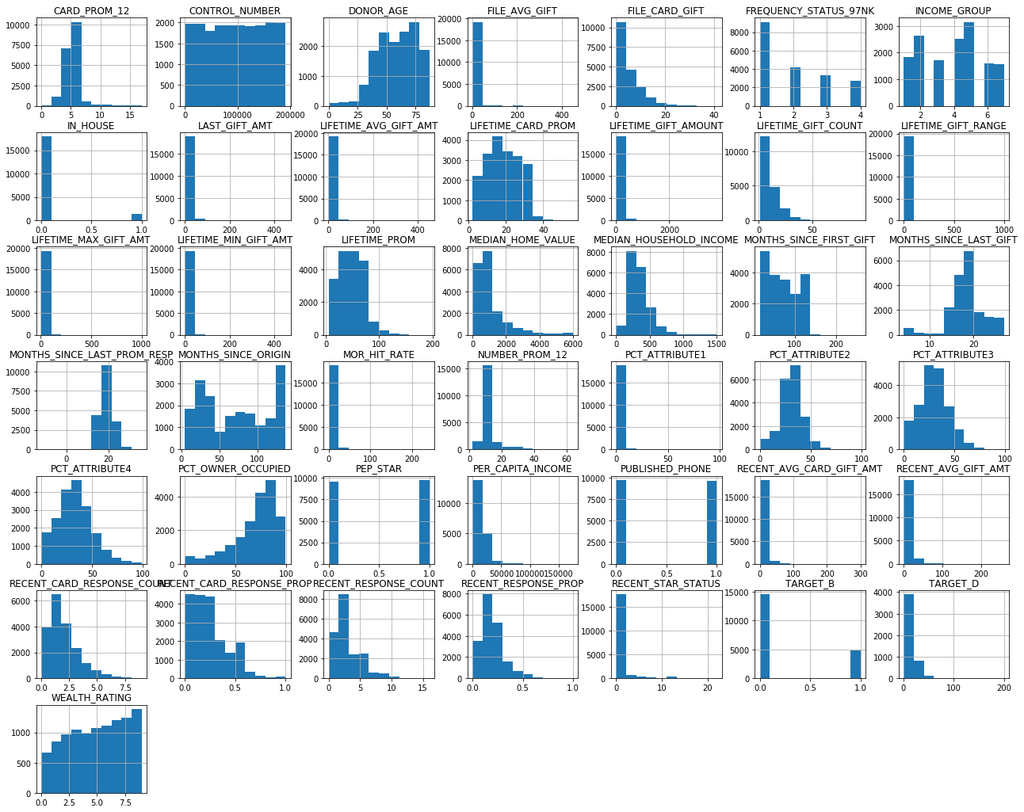

```python
donor_data.hist(figsize=(22,18))
plt.show()
```

**Table of Content**

# 4. Data Preparation

##### Dropped Columns:

[output not shown]

```python
# A new donor_dataset with dropped: 'TARGET_D', 'CONTROL_NUMBER' , 'HOME_OWNER' , 'INCOME_GROUP', OVERLAY_SOURCE
#                                    , 'WEALTH_RATING'

column_list = ['TARGET_B', 'MONTHS_SINCE_ORIGIN',
       'DONOR_AGE', 'IN_HOUSE', 'URBANICITY', 'SES', 'CLUSTER_CODE',
       'DONOR_GENDER', 'PUBLISHED_PHONE',
       'MOR_HIT_RATE', 'MEDIAN_HOME_VALUE',
       'MEDIAN_HOUSEHOLD_INCOME', 'PCT_OWNER_OCCUPIED', 'PER_CAPITA_INCOME',
       'PCT_ATTRIBUTE1', 'PCT_ATTRIBUTE2', 'PCT_ATTRIBUTE3', 'PCT_ATTRIBUTE4',
       'PEP_STAR', 'RECENT_STAR_STATUS', 'RECENCY_STATUS_96NK',
       'FREQUENCY_STATUS_97NK', 'RECENT_RESPONSE_PROP', 'RECENT_AVG_GIFT_AMT',
       'RECENT_CARD_RESPONSE_PROP', 'RECENT_AVG_CARD_GIFT_AMT',
       'RECENT_RESPONSE_COUNT', 'RECENT_CARD_RESPONSE_COUNT',
       'MONTHS_SINCE_LAST_PROM_RESP', 'LIFETIME_CARD_PROM', 'LIFETIME_PROM',
       'LIFETIME_GIFT_AMOUNT', 'LIFETIME_GIFT_COUNT', 'LIFETIME_AVG_GIFT_AMT',
       'LIFETIME_GIFT_RANGE', 'LIFETIME_MAX_GIFT_AMT', 'LIFETIME_MIN_GIFT_AMT',
       'LAST_GIFT_AMT', 'CARD_PROM_12', 'NUMBER_PROM_12',
       'MONTHS_SINCE_LAST_GIFT', 'MONTHS_SINCE_FIRST_GIFT', 'FILE_AVG_GIFT',
       'FILE_CARD_GIFT']
donor_dataset = donor_data[column_list]
```

```python
print(donor_dataset.shape)
```

```
(19372, 44)
```

### [ DONOR_AGE ]

**Handle missing values**

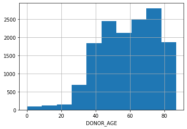

```python
donor_dataset['DONOR_AGE'].hist()
plt.xlabel('DONOR_AGE')
plt.show()
```

```python
# deal with age missing values

# calculate the mean and the median for the whole population

median_DONOR_AGE = donor_dataset['DONOR_AGE'].median()
print('Median = ',median_DONOR_AGE)
mean_DONOR_AGE = donor_dataset['DONOR_AGE'].mean()
print('Mean = ',mean_DONOR_AGE)
```

```
Median =  60.0
Mean =  58.91905055909995
```

Because the **distribution is not normal**, NaN values will be replaced with the **median**.

```python
donor_dataset['DONOR_AGE'].fillna(median_DONOR_AGE, inplace = True)
```

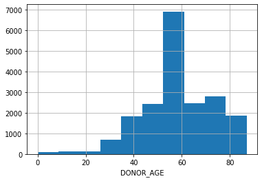

```python
donor_dataset['DONOR_AGE'].hist()
plt.xlabel('DONOR_AGE')
plt.show()
```

### [ MONTHS_SINCE_LAST_PROM_RESP ]

**Handle missing values**

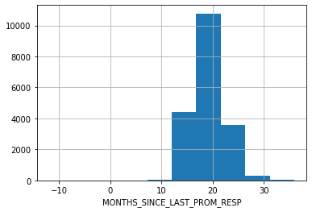

```python
donor_dataset['MONTHS_SINCE_LAST_PROM_RESP'].hist()
plt.xlabel('MONTHS_SINCE_LAST_PROM_RESP')
plt.show()
```

```python
median_MONTHS_SINCE_LAST_PROM_RESP = donor_dataset['MONTHS_SINCE_LAST_PROM_RESP'].median()
print('Median = ',median_MONTHS_SINCE_LAST_PROM_RESP)
mean_MONTHS_SINCE_LAST_PROM_RESP = donor_dataset['MONTHS_SINCE_LAST_PROM_RESP'].mean()
print('Mean = ',mean_MONTHS_SINCE_LAST_PROM_RESP)
```

```
Median =  18.0
Mean =  19.038899926801214
```

Because the distribution is quite **normal**, NaN values will be replaced with the **mean**.

```python
# replace NaN with the mean

donor_dataset['MONTHS_SINCE_LAST_PROM_RESP'].fillna(mean_MONTHS_SINCE_LAST_PROM_RESP, inplace = True)
```

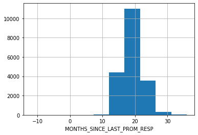

```python
donor_dataset['MONTHS_SINCE_LAST_PROM_RESP'].hist()
plt.xlabel('MONTHS_SINCE_LAST_PROM_RESP')
plt.show()
```

### [ SES ]

**Str values '1','2','3','4' replaced with numbers and '?' with number 5**.

```python
donor_dataset['SES'].replace('1',1,inplace=True)
donor_dataset['SES'].replace('2',2,inplace=True)
donor_dataset['SES'].replace('3',3,inplace=True)
donor_dataset['SES'].replace('4',4,inplace=True)
donor_dataset['SES'].replace('?',5,inplace=True)
```

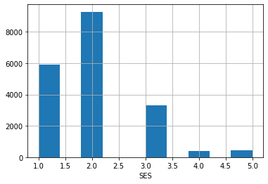

```
int64
```

|  | TARGET_B | MONTHS_SINCE_ORIGIN | DONOR_AGE | IN_HOUSE | URBANICITY | SES | CLUSTER_CODE | DONOR_GENDER | PUBLISHED_PHONE | MOR_HIT_RATE | MEDIAN_HOME_VALUE | MEDIAN_HOUSEHOLD_INCOME | PCT_OWNER_OCCUPIED | PER_CAPITA_INCOME | PCT_ATTRIBUTE1 | PCT_ATTRIBUTE2 | PCT_ATTRIBUTE3 | PCT_ATTRIBUTE4 | PEP_STAR | RECENT_STAR_STATUS | RECENCY_STATUS_96NK | FREQUENCY_STATUS_97NK | RECENT_RESPONSE_PROP | RECENT_AVG_GIFT_AMT | RECENT_CARD_RESPONSE_PROP | RECENT_AVG_CARD_GIFT_AMT | RECENT_RESPONSE_COUNT | RECENT_CARD_RESPONSE_COUNT | MONTHS_SINCE_LAST_PROM_RESP | … |
| --- | --- | --- | --- | --- | --- | --- | --- | --- | --- | --- | --- | --- | --- | --- | --- | --- | --- | --- | --- | --- | --- | --- | --- | --- | --- | --- | --- | --- | --- | --- |
| 0 | 0 | 101 | 87.0 | 0 | ? | 5 | . | M | 0 | 0 | 554 | 294 | 76 | 11855 | 0 | 0 | 0 | 0 | 1 | 0 | A | 1 | 0.067 | 15.00 | 0.000 | 0.00 | 1 | 0 | 26.0 | … |
| 1 | 1 | 137 | 79.0 | 0 | R | 2 | 45 | M | 0 | 0 | 334 | 212 | 72 | 10385 | 0 | 41 | 21 | 31 | 1 | 1 | S | 2 | 0.235 | 15.00 | 0.250 | 15.00 | 4 | 2 | 11.0 | … |
| 2 | 0 | 113 | 75.0 | 0 | S | 1 | 11 | F | 0 | 0 | 2388 | 405 | 63 | 30855 | 0 | 25 | 26 | 57 | 1 | 1 | S | 3 | 0.409 | 21.67 | 0.545 | 22.67 | 9 | 6 | 14.0 | … |
| 3 | 0 | 92 | 60.0 | 0 | U | 2 | 04 | F | 1 | 0 | 1688 | 153 | 3 | 16342 | 0 | 25 | 32 | 42 | 1 | 0 | A | 3 | 0.474 | 13.44 | 0.400 | 13.50 | 9 | 4 | 11.0 | … |
| 4 | 0 | 101 | 74.0 | 0 | R | 2 | 49 | F | 1 | 8 | 514 | 328 | 90 | 12107 | 0 | 33 | 36 | 37 | 0 | 0 | A | 1 | 0.100 | 17.50 | 0.111 | 10.00 | 2 | 1 | 18.0 | … |

```python
donor_dataset['SES'].hist()
plt.xlabel('SES')
plt.show()
print(donor_dataset['SES'].dtype)
donor_dataset.head(5)
```

### [ CLUSTER_CODE ]

**Replaced ' .' with the number '54' and after str values with numbers.**

```python
donor_dataset['CLUSTER_CODE'].replace(' .','54',inplace=True)
```

```python
donor_dataset['CLUSTER_CODE'] = donor_dataset['CLUSTER_CODE'].astype(int)
```

```
int32
```

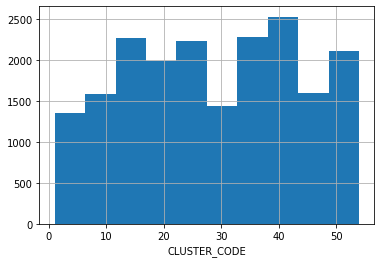

```python
print(donor_dataset['CLUSTER_CODE'].dtype)
donor_dataset['CLUSTER_CODE'].hist()
plt.xlabel('CLUSTER_CODE')
plt.show()
```

### [ DONOR_GENDER ]

**Dropped rows with gender inputted wrongly.**

```python
donor_dataset.shape
```

```
(19372, 44)
```

```python
donor_dataset['DONOR_GENDER'].unique()
```

```
array(['M', 'F', 'U', 'A'], dtype=object)
```

```python
# Get names of indexes for which column ['DONOR_GENDER'] has value 'U' and 'A'
indexNames_donor_U = donor_dataset[donor_dataset['DONOR_GENDER'] == 'U'].index    # U 1017 values
indexNames_donor_A = donor_dataset[donor_dataset['DONOR_GENDER'] == 'A'].index    # A 1 value

# Delete these row indexes from dataFrame
donor_dataset.drop(indexNames_donor_U, inplace=True)
donor_dataset.drop(indexNames_donor_A, inplace=True)
```

```python
donor_dataset.shape
```

```
(18354, 44)
```

```python
19372-18354
```

```
1018
```

```python
donor_dataset.to_csv('donor_prepared_for_analysis.csv',index=None)
```

**Replaced gender values with 1 for female, 0 for male with a categorical endoding.**

```python
donor_dataset['DONOR_GENDER'] = np.where(donor_dataset['DONOR_GENDER']=='F',1,0) # categorical encoding
```

```
(18354, 44)
```

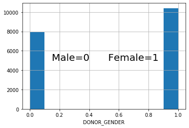

|  | TARGET_B | MONTHS_SINCE_ORIGIN | DONOR_AGE | IN_HOUSE | URBANICITY | SES | CLUSTER_CODE | DONOR_GENDER | PUBLISHED_PHONE | MOR_HIT_RATE | MEDIAN_HOME_VALUE | MEDIAN_HOUSEHOLD_INCOME | PCT_OWNER_OCCUPIED | PER_CAPITA_INCOME | PCT_ATTRIBUTE1 | PCT_ATTRIBUTE2 | PCT_ATTRIBUTE3 | PCT_ATTRIBUTE4 | PEP_STAR | RECENT_STAR_STATUS | RECENCY_STATUS_96NK | FREQUENCY_STATUS_97NK | RECENT_RESPONSE_PROP | RECENT_AVG_GIFT_AMT | RECENT_CARD_RESPONSE_PROP | RECENT_AVG_CARD_GIFT_AMT | RECENT_RESPONSE_COUNT | RECENT_CARD_RESPONSE_COUNT | MONTHS_SINCE_LAST_PROM_RESP | … |
| --- | --- | --- | --- | --- | --- | --- | --- | --- | --- | --- | --- | --- | --- | --- | --- | --- | --- | --- | --- | --- | --- | --- | --- | --- | --- | --- | --- | --- | --- | --- |
| 0 | 0 | 101 | 87.0 | 0 | ? | 5 | 54 | 0 | 0 | 0 | 554 | 294 | 76 | 11855 | 0 | 0 | 0 | 0 | 1 | 0 | A | 1 | 0.067 | 15.00 | 0.000 | 0.00 | 1 | 0 | 26.0 | … |
| 1 | 1 | 137 | 79.0 | 0 | R | 2 | 45 | 0 | 0 | 0 | 334 | 212 | 72 | 10385 | 0 | 41 | 21 | 31 | 1 | 1 | S | 2 | 0.235 | 15.00 | 0.250 | 15.00 | 4 | 2 | 11.0 | … |
| 2 | 0 | 113 | 75.0 | 0 | S | 1 | 11 | 1 | 0 | 0 | 2388 | 405 | 63 | 30855 | 0 | 25 | 26 | 57 | 1 | 1 | S | 3 | 0.409 | 21.67 | 0.545 | 22.67 | 9 | 6 | 14.0 | … |
| 3 | 0 | 92 | 60.0 | 0 | U | 2 | 4 | 1 | 1 | 0 | 1688 | 153 | 3 | 16342 | 0 | 25 | 32 | 42 | 1 | 0 | A | 3 | 0.474 | 13.44 | 0.400 | 13.50 | 9 | 4 | 11.0 | … |
| 4 | 0 | 101 | 74.0 | 0 | R | 2 | 49 | 1 | 1 | 8 | 514 | 328 | 90 | 12107 | 0 | 33 | 36 | 37 | 0 | 0 | A | 1 | 0.100 | 17.50 | 0.111 | 10.00 | 2 | 1 | 18.0 | … |

```python
print(donor_dataset.shape)
donor_dataset['DONOR_GENDER'].hist()
plt.xlabel('DONOR_GENDER')
plt.text(0.15, 5000, 'Male=0      Female=1',dict(size=20))
plt.show()
donor_dataset.head()
```

### [ URBANICITY ]

Replaced:

- ? -> 1
- R -> 2
- S -> 3
- U -> 4
- T -> 5
- C -> 6

```python
donor_dataset['URBANICITY'].replace('C',6,inplace=True)  # C = City
donor_dataset['URBANICITY'].replace('T',5,inplace=True)  # T = Town
donor_dataset['URBANICITY'].replace('U',4,inplace=True)  # U = Urban
donor_dataset['URBANICITY'].replace('S',3,inplace=True)  # S = Suburban
donor_dataset['URBANICITY'].replace('R',2,inplace=True)  # R = Rural
donor_dataset['URBANICITY'].replace('?',1,inplace=True)  # ? = Unknown
donor_dataset.head()
```

|  | TARGET_B | MONTHS_SINCE_ORIGIN | DONOR_AGE | IN_HOUSE | URBANICITY | SES | CLUSTER_CODE | DONOR_GENDER | PUBLISHED_PHONE | MOR_HIT_RATE | MEDIAN_HOME_VALUE | MEDIAN_HOUSEHOLD_INCOME | PCT_OWNER_OCCUPIED | PER_CAPITA_INCOME | PCT_ATTRIBUTE1 | PCT_ATTRIBUTE2 | PCT_ATTRIBUTE3 | PCT_ATTRIBUTE4 | PEP_STAR | RECENT_STAR_STATUS | RECENCY_STATUS_96NK | FREQUENCY_STATUS_97NK | RECENT_RESPONSE_PROP | RECENT_AVG_GIFT_AMT | RECENT_CARD_RESPONSE_PROP | RECENT_AVG_CARD_GIFT_AMT | RECENT_RESPONSE_COUNT | RECENT_CARD_RESPONSE_COUNT | MONTHS_SINCE_LAST_PROM_RESP | … |
| --- | --- | --- | --- | --- | --- | --- | --- | --- | --- | --- | --- | --- | --- | --- | --- | --- | --- | --- | --- | --- | --- | --- | --- | --- | --- | --- | --- | --- | --- | --- |
| 0 | 0 | 101 | 87.0 | 0 | 1 | 5 | 54 | 0 | 0 | 0 | 554 | 294 | 76 | 11855 | 0 | 0 | 0 | 0 | 1 | 0 | A | 1 | 0.067 | 15.00 | 0.000 | 0.00 | 1 | 0 | 26.0 | … |
| 1 | 1 | 137 | 79.0 | 0 | 2 | 2 | 45 | 0 | 0 | 0 | 334 | 212 | 72 | 10385 | 0 | 41 | 21 | 31 | 1 | 1 | S | 2 | 0.235 | 15.00 | 0.250 | 15.00 | 4 | 2 | 11.0 | … |
| 2 | 0 | 113 | 75.0 | 0 | 3 | 1 | 11 | 1 | 0 | 0 | 2388 | 405 | 63 | 30855 | 0 | 25 | 26 | 57 | 1 | 1 | S | 3 | 0.409 | 21.67 | 0.545 | 22.67 | 9 | 6 | 14.0 | … |
| 3 | 0 | 92 | 60.0 | 0 | 4 | 2 | 4 | 1 | 1 | 0 | 1688 | 153 | 3 | 16342 | 0 | 25 | 32 | 42 | 1 | 0 | A | 3 | 0.474 | 13.44 | 0.400 | 13.50 | 9 | 4 | 11.0 | … |
| 4 | 0 | 101 | 74.0 | 0 | 2 | 2 | 49 | 1 | 1 | 8 | 514 | 328 | 90 | 12107 | 0 | 33 | 36 | 37 | 0 | 0 | A | 1 | 0.100 | 17.50 | 0.111 | 10.00 | 2 | 1 | 18.0 | … |

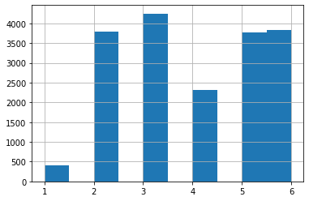

```python
donor_dataset['URBANICITY'].hist()
plt.show()
```

### RECENCY_STATUS_96NK

Replaced:

- A -> 1
- E -> 2
- F -> 3
- L -> 4
- N -> 5
- S -> 6

```python
donor_dataset['RECENCY_STATUS_96NK'].replace('A',1,inplace=True)
donor_dataset['RECENCY_STATUS_96NK'].replace('E',2,inplace=True)
donor_dataset['RECENCY_STATUS_96NK'].replace('F',3,inplace=True)
donor_dataset['RECENCY_STATUS_96NK'].replace('L',4,inplace=True)
donor_dataset['RECENCY_STATUS_96NK'].replace('N',5,inplace=True)
donor_dataset['RECENCY_STATUS_96NK'].replace('S',6,inplace=True)
donor_dataset.head()
```

|  | TARGET_B | MONTHS_SINCE_ORIGIN | DONOR_AGE | IN_HOUSE | URBANICITY | SES | CLUSTER_CODE | DONOR_GENDER | PUBLISHED_PHONE | MOR_HIT_RATE | MEDIAN_HOME_VALUE | MEDIAN_HOUSEHOLD_INCOME | PCT_OWNER_OCCUPIED | PER_CAPITA_INCOME | PCT_ATTRIBUTE1 | PCT_ATTRIBUTE2 | PCT_ATTRIBUTE3 | PCT_ATTRIBUTE4 | PEP_STAR | RECENT_STAR_STATUS | RECENCY_STATUS_96NK | FREQUENCY_STATUS_97NK | RECENT_RESPONSE_PROP | RECENT_AVG_GIFT_AMT | RECENT_CARD_RESPONSE_PROP | RECENT_AVG_CARD_GIFT_AMT | RECENT_RESPONSE_COUNT | RECENT_CARD_RESPONSE_COUNT | MONTHS_SINCE_LAST_PROM_RESP | … |
| --- | --- | --- | --- | --- | --- | --- | --- | --- | --- | --- | --- | --- | --- | --- | --- | --- | --- | --- | --- | --- | --- | --- | --- | --- | --- | --- | --- | --- | --- | --- |
| 0 | 0 | 101 | 87.0 | 0 | 1 | 5 | 54 | 0 | 0 | 0 | 554 | 294 | 76 | 11855 | 0 | 0 | 0 | 0 | 1 | 0 | 1 | 1 | 0.067 | 15.00 | 0.000 | 0.00 | 1 | 0 | 26.0 | … |
| 1 | 1 | 137 | 79.0 | 0 | 2 | 2 | 45 | 0 | 0 | 0 | 334 | 212 | 72 | 10385 | 0 | 41 | 21 | 31 | 1 | 1 | 6 | 2 | 0.235 | 15.00 | 0.250 | 15.00 | 4 | 2 | 11.0 | … |
| 2 | 0 | 113 | 75.0 | 0 | 3 | 1 | 11 | 1 | 0 | 0 | 2388 | 405 | 63 | 30855 | 0 | 25 | 26 | 57 | 1 | 1 | 6 | 3 | 0.409 | 21.67 | 0.545 | 22.67 | 9 | 6 | 14.0 | … |
| 3 | 0 | 92 | 60.0 | 0 | 4 | 2 | 4 | 1 | 1 | 0 | 1688 | 153 | 3 | 16342 | 0 | 25 | 32 | 42 | 1 | 0 | 1 | 3 | 0.474 | 13.44 | 0.400 | 13.50 | 9 | 4 | 11.0 | … |
| 4 | 0 | 101 | 74.0 | 0 | 2 | 2 | 49 | 1 | 1 | 8 | 514 | 328 | 90 | 12107 | 0 | 33 | 36 | 37 | 0 | 0 | 1 | 1 | 0.100 | 17.50 | 0.111 | 10.00 | 2 | 1 | 18.0 | … |

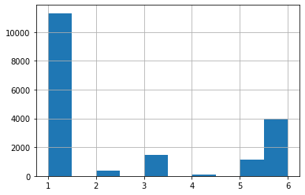

```python
donor_dataset['RECENCY_STATUS_96NK'].hist()
plt.show()
```

##### Data Distributions (Histograms) - Before Data Preparation

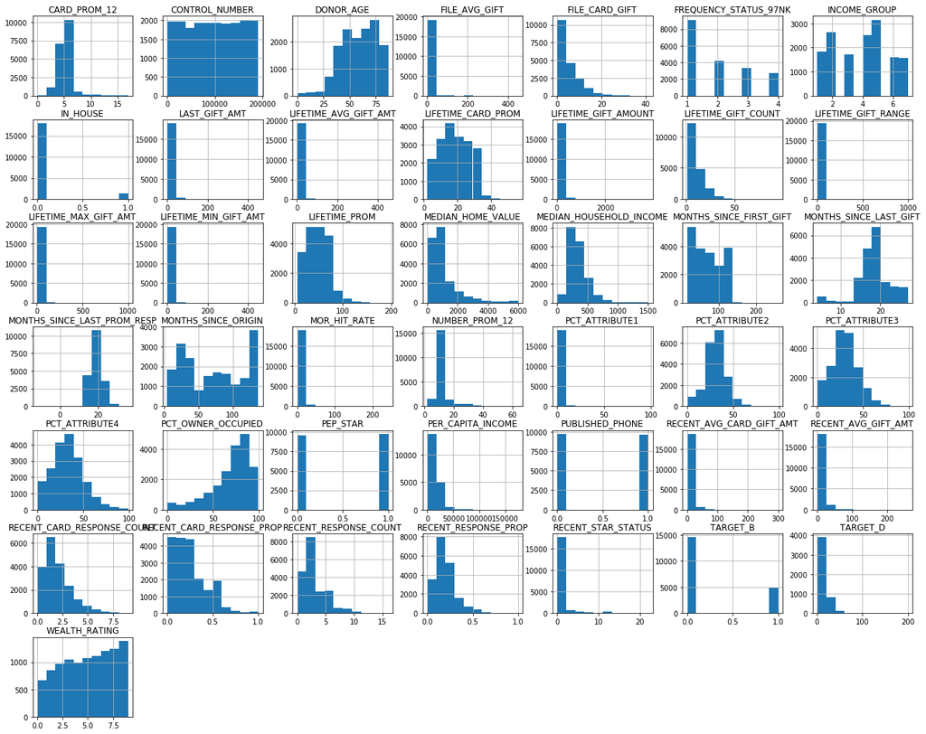

```python
donor_data.hist(figsize=(22,18))
plt.show()
```

##### Data Distributions (Histograms) - After Data Preparation

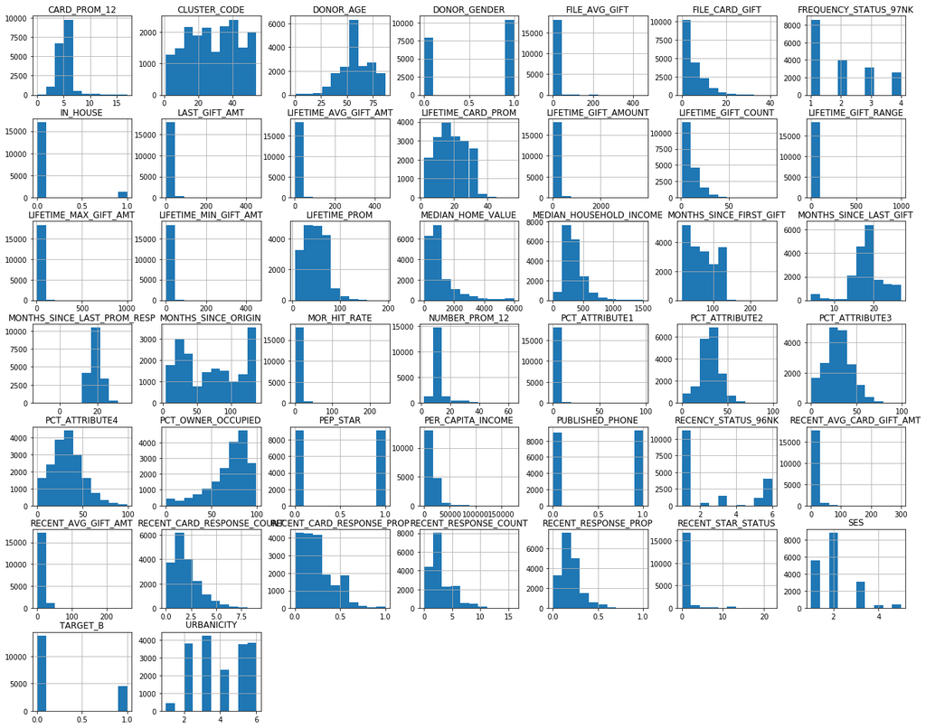

```python
donor_dataset.hist(figsize=(22,18))
plt.show()
```

### [ TARGET_B ]

```
The shape is:  (18354, 44)
0=no 1=yes
 TARGET_B
0    13783
1     4571
dtype: int64
```

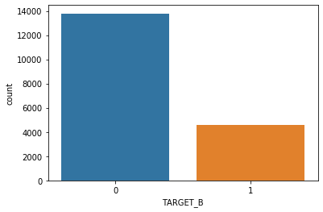

```python
print('The shape is: ', donor_dataset.shape)
print('0=no 1=yes','\n',donor_dataset.groupby('TARGET_B').size())
sns.countplot(donor_dataset['TARGET_B'])
```

### TARGET_B (response to sollicitation) 0 = No , 1 = Yes

- Of these 18354 data points, 13783 are labeled as 0 and 4571 as 1:
  - Unbalanced DataSet

### Prepare Data for Scaling

```python
donor_dataset
```

|  | TARGET_B | MONTHS_SINCE_ORIGIN | DONOR_AGE | IN_HOUSE | URBANICITY | SES | CLUSTER_CODE | DONOR_GENDER | PUBLISHED_PHONE | MOR_HIT_RATE | MEDIAN_HOME_VALUE | MEDIAN_HOUSEHOLD_INCOME | PCT_OWNER_OCCUPIED | PER_CAPITA_INCOME | PCT_ATTRIBUTE1 | PCT_ATTRIBUTE2 | PCT_ATTRIBUTE3 | PCT_ATTRIBUTE4 | PEP_STAR | RECENT_STAR_STATUS | RECENCY_STATUS_96NK | FREQUENCY_STATUS_97NK | RECENT_RESPONSE_PROP | RECENT_AVG_GIFT_AMT | RECENT_CARD_RESPONSE_PROP | RECENT_AVG_CARD_GIFT_AMT | RECENT_RESPONSE_COUNT | RECENT_CARD_RESPONSE_COUNT | MONTHS_SINCE_LAST_PROM_RESP | … |
| --- | --- | --- | --- | --- | --- | --- | --- | --- | --- | --- | --- | --- | --- | --- | --- | --- | --- | --- | --- | --- | --- | --- | --- | --- | --- | --- | --- | --- | --- | --- |
| 0 | 0 | 101 | 87.0 | 0 | 1 | 5 | 54 | 0 | 0 | 0 | 554 | 294 | 76 | 11855 | 0 | 0 | 0 | 0 | 1 | 0 | 1 | 1 | 0.067 | 15.00 | 0.000 | 0.00 | 1 | 0 | 26.0000 | … |
| 1 | 1 | 137 | 79.0 | 0 | 2 | 2 | 45 | 0 | 0 | 0 | 334 | 212 | 72 | 10385 | 0 | 41 | 21 | 31 | 1 | 1 | 6 | 2 | 0.235 | 15.00 | 0.250 | 15.00 | 4 | 2 | 11.0000 | … |
| 2 | 0 | 113 | 75.0 | 0 | 3 | 1 | 11 | 1 | 0 | 0 | 2388 | 405 | 63 | 30855 | 0 | 25 | 26 | 57 | 1 | 1 | 6 | 3 | 0.409 | 21.67 | 0.545 | 22.67 | 9 | 6 | 14.0000 | … |
| 3 | 0 | 92 | 60.0 | 0 | 4 | 2 | 4 | 1 | 1 | 0 | 1688 | 153 | 3 | 16342 | 0 | 25 | 32 | 42 | 1 | 0 | 1 | 3 | 0.474 | 13.44 | 0.400 | 13.50 | 9 | 4 | 11.0000 | … |
| 4 | 0 | 101 | 74.0 | 0 | 2 | 2 | 49 | 1 | 1 | 8 | 514 | 328 | 90 | 12107 | 0 | 33 | 36 | 37 | 0 | 0 | 1 | 1 | 0.100 | 17.50 | 0.111 | 10.00 | 2 | 1 | 18.0000 | … |
| ... | ... | ... | ... | ... | ... | ... | ... | ... | ... | ... | ... | ... | ... | ... | ... | ... | ... | ... | ... | ... | ... | ... | ... | ... | ... | ... | ... | ... | ... | … |
| 19367 | 0 | 89 | 66.0 | 1 | 4 | 1 | 3 | 1 | 1 | 241 | 1224 | 411 | 53 | 17457 | 1 | 24 | 34 | 41 | 0 | 0 | 1 | 2 | 0.154 | 15.00 | 0.167 | 15.00 | 2 | 1 | 18.0000 | … |
| 19368 | 0 | 137 | 77.0 | 1 | 6 | 1 | 24 | 1 | 1 | 240 | 778 | 388 | 67 | 18431 | 3 | 36 | 28 | 56 | 1 | 1 | 6 | 3 | 0.200 | 9.00 | 0.200 | 10.00 | 4 | 2 | 21.0000 | … |
| 19369 | 0 | 29 | 60.0 | 1 | 3 | 1 | 11 | 0 | 1 | 0 | 383 | 203 | 74 | 11971 | 0 | 41 | 20 | 58 | 0 | 0 | 5 | 1 | 0.000 | 0.00 | 0.000 | 0.00 | 0 | 0 | 19.0389 | … |
| 19370 | 0 | 129 | 78.0 | 1 | 1 | 5 | 54 | 0 | 1 | 0 | 1861 | 421 | 84 | 22294 | 0 | 0 | 0 | 0 | 1 | 14 | 1 | 1 | 0.053 | 25.00 | 0.000 | 0.00 | 1 | 0 | 23.0000 | … |
| 19371 | 1 | 29 | 70.0 | 0 | 1 | 5 | 54 | 0 | 1 | 2 | 1432 | 636 | 98 | 35544 | 0 | 62 | 13 | 61 | 0 | 0 | 5 | 1 | 0.100 | 25.00 | 0.250 | 25.00 | 1 | 1 | 24.0000 | … |

18354 rows × 44 columns

```python
TARGET_B = donor_dataset['TARGET_B']
print(TARGET_B.shape, type(TARGET_B))
TARGET_B
```

```
(18354,) <class 'pandas.core.series.Series'>
```

```
0        0
1        1
2        0
3        0
4        0
        ..
19367    0
19368    0
19369    0
19370    0
19371    1
Name: TARGET_B, Length: 18354, dtype: int64
```

```python
TARGET_B_np = TARGET_B.to_numpy()
print(TARGET_B_np.shape, type(TARGET_B_np))
TARGET_B_np
```

```
(18354,) <class 'numpy.ndarray'>
```

```
array([0, 1, 0, ..., 0, 0, 1], dtype=int64)
```

```python
TARGET_B_df = pd.DataFrame(TARGET_B_np)
TARGET_B_df.columns = ['TARGET_B']
print(TARGET_B_df.shape, type(TARGET_B_df))
TARGET_B_df
```

```
(18354, 1) <class 'pandas.core.frame.DataFrame'>
```

|  | TARGET_B |
| --- | --- |
| 0 | 0 |
| 1 | 1 |
| 2 | 0 |
| 3 | 0 |
| 4 | 0 |
| ... | ... |
| 18349 | 0 |
| 18350 | 0 |
| 18351 | 0 |
| 18352 | 0 |
| 18353 | 1 |

18354 rows × 1 columns

```python
donor_dataset2 = donor_dataset.drop('TARGET_B',axis=1)
```

```python
print(donor_dataset2.shape)
donor_dataset2.tail()
```

```
(18354, 43)
```

|  | MONTHS_SINCE_ORIGIN | DONOR_AGE | IN_HOUSE | URBANICITY | SES | CLUSTER_CODE | DONOR_GENDER | PUBLISHED_PHONE | MOR_HIT_RATE | MEDIAN_HOME_VALUE | MEDIAN_HOUSEHOLD_INCOME | PCT_OWNER_OCCUPIED | PER_CAPITA_INCOME | PCT_ATTRIBUTE1 | PCT_ATTRIBUTE2 | PCT_ATTRIBUTE3 | PCT_ATTRIBUTE4 | PEP_STAR | RECENT_STAR_STATUS | RECENCY_STATUS_96NK | FREQUENCY_STATUS_97NK | RECENT_RESPONSE_PROP | RECENT_AVG_GIFT_AMT | RECENT_CARD_RESPONSE_PROP | RECENT_AVG_CARD_GIFT_AMT | RECENT_RESPONSE_COUNT | RECENT_CARD_RESPONSE_COUNT | MONTHS_SINCE_LAST_PROM_RESP | LIFETIME_CARD_PROM | … |
| --- | --- | --- | --- | --- | --- | --- | --- | --- | --- | --- | --- | --- | --- | --- | --- | --- | --- | --- | --- | --- | --- | --- | --- | --- | --- | --- | --- | --- | --- | --- |
| 19367 | 89 | 66.0 | 1 | 4 | 1 | 3 | 1 | 1 | 241 | 1224 | 411 | 53 | 17457 | 1 | 24 | 34 | 41 | 0 | 0 | 1 | 2 | 0.154 | 15.0 | 0.167 | 15.0 | 2 | 1 | 18.0000 | 18 | … |
| 19368 | 137 | 77.0 | 1 | 6 | 1 | 24 | 1 | 1 | 240 | 778 | 388 | 67 | 18431 | 3 | 36 | 28 | 56 | 1 | 1 | 6 | 3 | 0.200 | 9.0 | 0.200 | 10.0 | 4 | 2 | 21.0000 | 32 | … |
| 19369 | 29 | 60.0 | 1 | 3 | 1 | 11 | 0 | 1 | 0 | 383 | 203 | 74 | 11971 | 0 | 41 | 20 | 58 | 0 | 0 | 5 | 1 | 0.000 | 0.0 | 0.000 | 0.0 | 0 | 0 | 19.0389 | 5 | … |
| 19370 | 129 | 78.0 | 1 | 1 | 5 | 54 | 0 | 1 | 0 | 1861 | 421 | 84 | 22294 | 0 | 0 | 0 | 0 | 1 | 14 | 1 | 1 | 0.053 | 25.0 | 0.000 | 0.0 | 1 | 0 | 23.0000 | 31 | … |
| 19371 | 29 | 70.0 | 0 | 1 | 5 | 54 | 0 | 1 | 2 | 1432 | 636 | 98 | 35544 | 0 | 62 | 13 | 61 | 0 | 0 | 5 | 1 | 0.100 | 25.0 | 0.250 | 25.0 | 1 | 1 | 24.0000 | 7 | … |

```python
print(donor_dataset2.columns)
```

```
Index(['MONTHS_SINCE_ORIGIN', 'DONOR_AGE', 'IN_HOUSE', 'URBANICITY', 'SES',
       'CLUSTER_CODE', 'DONOR_GENDER', 'PUBLISHED_PHONE', 'MOR_HIT_RATE',
       'MEDIAN_HOME_VALUE', 'MEDIAN_HOUSEHOLD_INCOME', 'PCT_OWNER_OCCUPIED',
       'PER_CAPITA_INCOME', 'PCT_ATTRIBUTE1', 'PCT_ATTRIBUTE2',
       'PCT_ATTRIBUTE3', 'PCT_ATTRIBUTE4', 'PEP_STAR', 'RECENT_STAR_STATUS',
       'RECENCY_STATUS_96NK', 'FREQUENCY_STATUS_97NK', 'RECENT_RESPONSE_PROP',
       'RECENT_AVG_GIFT_AMT', 'RECENT_CARD_RESPONSE_PROP',
       'RECENT_AVG_CARD_GIFT_AMT', 'RECENT_RESPONSE_COUNT',
       'RECENT_CARD_RESPONSE_COUNT', 'MONTHS_SINCE_LAST_PROM_RESP',
       'LIFETIME_CARD_PROM', 'LIFETIME_PROM', 'LIFETIME_GIFT_AMOUNT',
       'LIFETIME_GIFT_COUNT', 'LIFETIME_AVG_GIFT_AMT', 'LIFETIME_GIFT_RANGE',
       'LIFETIME_MAX_GIFT_AMT', 'LIFETIME_MIN_GIFT_AMT', 'LAST_GIFT_AMT',
       'CARD_PROM_12', 'NUMBER_PROM_12', 'MONTHS_SINCE_LAST_GIFT',
       'MONTHS_SINCE_FIRST_GIFT', 'FILE_AVG_GIFT', 'FILE_CARD_GIFT'],
      dtype='object')
```

- **TARGET_B_df**
- **donor_dataset2**

## Scaling

##### Standard Scaler

```python
# create StandardScaler() object
scaler_standard = preprocessing.StandardScaler()

# transform data and store it in scaled_standard
scaled_standard = scaler_standard.fit_transform(donor_dataset2)

# convert scaled_standard to DataFrame
scaled_standard_df = pd.DataFrame(scaled_standard, columns=['MONTHS_SINCE_ORIGIN', 'DONOR_AGE', 'IN_HOUSE', 'URBANICITY', 'SES',
       'CLUSTER_CODE', 'DONOR_GENDER', 'PUBLISHED_PHONE', 'MOR_HIT_RATE',
       'MEDIAN_HOME_VALUE', 'MEDIAN_HOUSEHOLD_INCOME', 'PCT_OWNER_OCCUPIED',
       'PER_CAPITA_INCOME', 'PCT_ATTRIBUTE1', 'PCT_ATTRIBUTE2',
       'PCT_ATTRIBUTE3', 'PCT_ATTRIBUTE4', 'PEP_STAR', 'RECENT_STAR_STATUS',
       'RECENCY_STATUS_96NK', 'FREQUENCY_STATUS_97NK', 'RECENT_RESPONSE_PROP',
       'RECENT_AVG_GIFT_AMT', 'RECENT_CARD_RESPONSE_PROP',
       'RECENT_AVG_CARD_GIFT_AMT', 'RECENT_RESPONSE_COUNT',
       'RECENT_CARD_RESPONSE_COUNT', 'MONTHS_SINCE_LAST_PROM_RESP',
       'LIFETIME_CARD_PROM', 'LIFETIME_PROM', 'LIFETIME_GIFT_AMOUNT',
       'LIFETIME_GIFT_COUNT', 'LIFETIME_AVG_GIFT_AMT', 'LIFETIME_GIFT_RANGE',
       'LIFETIME_MAX_GIFT_AMT', 'LIFETIME_MIN_GIFT_AMT', 'LAST_GIFT_AMT',
       'CARD_PROM_12', 'NUMBER_PROM_12', 'MONTHS_SINCE_LAST_GIFT',
       'MONTHS_SINCE_FIRST_GIFT', 'FILE_AVG_GIFT', 'FILE_CARD_GIFT'])
```

```python
print(scaled_standard_df.shape)
scaled_standard_df.tail()
```

```
(18354, 43)
```

|  | MONTHS_SINCE_ORIGIN | DONOR_AGE | IN_HOUSE | URBANICITY | SES | CLUSTER_CODE | DONOR_GENDER | PUBLISHED_PHONE | MOR_HIT_RATE | MEDIAN_HOME_VALUE | MEDIAN_HOUSEHOLD_INCOME | PCT_OWNER_OCCUPIED | PER_CAPITA_INCOME | PCT_ATTRIBUTE1 | PCT_ATTRIBUTE2 | PCT_ATTRIBUTE3 | PCT_ATTRIBUTE4 | PEP_STAR | RECENT_STAR_STATUS | RECENCY_STATUS_96NK | FREQUENCY_STATUS_97NK | RECENT_RESPONSE_PROP | RECENT_AVG_GIFT_AMT | RECENT_CARD_RESPONSE_PROP | RECENT_AVG_CARD_GIFT_AMT | RECENT_RESPONSE_COUNT | RECENT_CARD_RESPONSE_COUNT | MONTHS_SINCE_LAST_PROM_RESP | LIFETIME_CARD_PROM | … |
| --- | --- | --- | --- | --- | --- | --- | --- | --- | --- | --- | --- | --- | --- | --- | --- | --- | --- | --- | --- | --- | --- | --- | --- | --- | --- | --- | --- | --- | --- | --- |
| 18349 | 0.390331 | 0.468646 | 3.533507 | 0.059045 | -1.116013 | -1.723905 | 0.874436 | 0.985289 | 24.534314 | 0.151421 | 0.418036 | -0.777418 | 0.183606 | -0.004363 | -0.585140 | 0.287085 | 0.454621 | -1.000436 | -0.363984 | -0.722585 | 0.014880 | -0.316185 | -0.037725 | -0.341054 | 0.302103 | -0.508830 | -0.473998 | -0.304507 | -0.069706 | … |
| 18350 | 1.555826 | 1.220779 | 3.533507 | 1.379840 | -1.116013 | -0.303621 | 0.874436 | 0.985289 | 24.431026 | -0.312764 | 0.277991 | -0.130165 | 0.295453 | 0.406274 | 0.470329 | -0.110883 | 1.297415 | 0.999564 | 0.032842 | 1.642562 | 0.925227 | 0.090990 | -0.624617 | -0.163038 | -0.156141 | 0.470005 | 0.178500 | 0.578884 | 1.567978 | … |
| 18351 | -1.066538 | 0.058392 | 3.533507 | -0.601352 | -1.116013 | -1.182844 | -1.143594 | 0.985289 | -0.358092 | -0.723869 | -0.848462 | 0.193461 | -0.446367 | -0.209681 | 0.910107 | -0.641505 | 1.409788 | -1.000436 | -0.363984 | 1.169533 | -0.895467 | -1.679336 | -1.504954 | -1.241918 | -1.072628 | -1.487666 | -1.126496 | 0.001412 | -1.590413 | … |
| 18352 | 1.361577 | 1.289154 | 3.533507 | -1.922147 | 3.477169 | 1.725357 | -1.143594 | 0.985289 | -0.358092 | 0.814393 | 0.478926 | 0.655784 | 0.739053 | -0.209681 | -2.696077 | -1.968062 | -1.849017 | 0.999564 | 5.191571 | -0.722585 | -0.895467 | -1.210200 | 0.940427 | -1.241918 | -1.072628 | -0.998248 | -1.126496 | 1.167811 | 1.451001 | … |
| 18353 | -1.066538 | 0.742149 | -0.283005 | -1.922147 | 3.477169 | 1.725357 | -1.143594 | 0.985289 | -0.151516 | 0.367901 | 1.788046 | 1.303036 | 2.260588 | -0.209681 | 2.757177 | -1.105800 | 1.578347 | -1.000436 | -0.363984 | 1.169533 | -0.895467 | -0.794173 | 0.940427 | 0.106681 | 1.218590 | -0.998248 | -0.473998 | 1.462275 | -1.356458 | … |

```python
donor_dataset_scaled_standard = TARGET_B_df.join(scaled_standard_df, how='right')
```

```python
donor_dataset_scaled_standard
```

|  | TARGET_B | MONTHS_SINCE_ORIGIN | DONOR_AGE | IN_HOUSE | URBANICITY | SES | CLUSTER_CODE | DONOR_GENDER | PUBLISHED_PHONE | MOR_HIT_RATE | MEDIAN_HOME_VALUE | MEDIAN_HOUSEHOLD_INCOME | PCT_OWNER_OCCUPIED | PER_CAPITA_INCOME | PCT_ATTRIBUTE1 | PCT_ATTRIBUTE2 | PCT_ATTRIBUTE3 | PCT_ATTRIBUTE4 | PEP_STAR | RECENT_STAR_STATUS | RECENCY_STATUS_96NK | FREQUENCY_STATUS_97NK | RECENT_RESPONSE_PROP | RECENT_AVG_GIFT_AMT | RECENT_CARD_RESPONSE_PROP | RECENT_AVG_CARD_GIFT_AMT | RECENT_RESPONSE_COUNT | RECENT_CARD_RESPONSE_COUNT | MONTHS_SINCE_LAST_PROM_RESP | … |
| --- | --- | --- | --- | --- | --- | --- | --- | --- | --- | --- | --- | --- | --- | --- | --- | --- | --- | --- | --- | --- | --- | --- | --- | --- | --- | --- | --- | --- | --- | --- |
| 0 | 0 | 0.681705 | 1.904536 | -0.283005 | -1.922147 | 3.477169 | 1.725357 | -1.143594 | -1.014931 | -0.358092 | -0.545897 | -0.294369 | 0.285925 | -0.459688 | -0.209681 | -2.696077 | -1.968062 | -1.849017 | 0.999564 | -0.363984 | -0.722585 | -0.895467 | -1.086277 | -0.037725 | -1.241918 | -1.072628 | -0.998248 | -1.126496 | 2.051202 | … |
| 1 | 1 | 1.555826 | 1.357530 | -0.283005 | -1.261750 | 0.032283 | 1.116664 | -1.143594 | -1.014931 | -0.358092 | -0.774867 | -0.793661 | 0.100996 | -0.628492 | -0.209681 | 0.910107 | -0.575178 | -0.107242 | 0.999564 | 0.032842 | 1.642562 | 0.014880 | 0.400797 | -0.037725 | 0.106681 | 0.302103 | 0.470005 | 0.178500 | -2.365752 | … |
| 2 | 0 | 0.973078 | 1.084027 | -0.283005 | -0.601352 | -1.116013 | -1.182844 | 0.874436 | -1.014931 | -0.358092 | 1.362880 | 0.381503 | -0.315095 | 1.722137 | -0.209681 | -0.497184 | -0.243538 | 1.353601 | 0.999564 | 0.032842 | 1.642562 | 0.925227 | 1.940981 | 0.614702 | 1.698029 | 1.005048 | 2.917094 | 2.788492 | -1.482361 | … |
| 3 | 0 | 0.463174 | 0.058392 | -0.283005 | 0.059045 | 0.032283 | -1.656272 | 0.874436 | 0.985289 | -0.358092 | 0.634339 | -1.152908 | -3.089033 | 0.055567 | -0.209681 | -0.497184 | 0.154429 | 0.510807 | 0.999564 | -0.363984 | -0.722585 | 0.925227 | 2.516337 | -0.190317 | 0.915841 | 0.164630 | 2.917094 | 1.483496 | -2.365752 | … |
| 4 | 0 | 0.681705 | 1.015651 | -0.283005 | -1.261750 | 0.032283 | 1.387194 | 0.874436 | 0.985289 | 0.468212 | -0.587528 | -0.087345 | 0.933178 | -0.430750 | -0.209681 | 0.206462 | 0.419740 | 0.229876 | -1.000436 | -0.363984 | -0.722585 | -0.895467 | -0.794173 | 0.206813 | -0.643140 | -0.156141 | -0.508830 | -0.473998 | -0.304507 | … |
| ... | ... | ... | ... | ... | ... | ... | ... | ... | ... | ... | ... | ... | ... | ... | ... | ... | ... | ... | ... | ... | ... | ... | ... | ... | ... | ... | ... | ... | ... | … |
| 18349 | 0 | 0.390331 | 0.468646 | 3.533507 | 0.059045 | -1.116013 | -1.723905 | 0.874436 | 0.985289 | 24.534314 | 0.151421 | 0.418036 | -0.777418 | 0.183606 | -0.004363 | -0.585140 | 0.287085 | 0.454621 | -1.000436 | -0.363984 | -0.722585 | 0.014880 | -0.316185 | -0.037725 | -0.341054 | 0.302103 | -0.508830 | -0.473998 | -0.304507 | … |
| 18350 | 0 | 1.555826 | 1.220779 | 3.533507 | 1.379840 | -1.116013 | -0.303621 | 0.874436 | 0.985289 | 24.431026 | -0.312764 | 0.277991 | -0.130165 | 0.295453 | 0.406274 | 0.470329 | -0.110883 | 1.297415 | 0.999564 | 0.032842 | 1.642562 | 0.925227 | 0.090990 | -0.624617 | -0.163038 | -0.156141 | 0.470005 | 0.178500 | 0.578884 | … |
| 18351 | 0 | -1.066538 | 0.058392 | 3.533507 | -0.601352 | -1.116013 | -1.182844 | -1.143594 | 0.985289 | -0.358092 | -0.723869 | -0.848462 | 0.193461 | -0.446367 | -0.209681 | 0.910107 | -0.641505 | 1.409788 | -1.000436 | -0.363984 | 1.169533 | -0.895467 | -1.679336 | -1.504954 | -1.241918 | -1.072628 | -1.487666 | -1.126496 | 0.001412 | … |
| 18352 | 0 | 1.361577 | 1.289154 | 3.533507 | -1.922147 | 3.477169 | 1.725357 | -1.143594 | 0.985289 | -0.358092 | 0.814393 | 0.478926 | 0.655784 | 0.739053 | -0.209681 | -2.696077 | -1.968062 | -1.849017 | 0.999564 | 5.191571 | -0.722585 | -0.895467 | -1.210200 | 0.940427 | -1.241918 | -1.072628 | -0.998248 | -1.126496 | 1.167811 | … |
| 18353 | 1 | -1.066538 | 0.742149 | -0.283005 | -1.922147 | 3.477169 | 1.725357 | -1.143594 | 0.985289 | -0.151516 | 0.367901 | 1.788046 | 1.303036 | 2.260588 | -0.209681 | 2.757177 | -1.105800 | 1.578347 | -1.000436 | -0.363984 | 1.169533 | -0.895467 | -0.794173 | 0.940427 | 0.106681 | 1.218590 | -0.998248 | -0.473998 | 1.462275 | … |

18354 rows × 44 columns

##### Robust Scaler

```python
# create RobustScaler() object
scaler_robust = preprocessing.RobustScaler()

# transform data and store it in scaled_robust
scaled_robust = scaler_robust.fit_transform(donor_dataset2)

# convert scaled_robust to DataFrame
scaled_robust_df = pd.DataFrame(scaled_robust, columns=['MONTHS_SINCE_ORIGIN', 'DONOR_AGE', 'IN_HOUSE', 'URBANICITY', 'SES',
       'CLUSTER_CODE', 'DONOR_GENDER', 'PUBLISHED_PHONE', 'MOR_HIT_RATE',
       'MEDIAN_HOME_VALUE', 'MEDIAN_HOUSEHOLD_INCOME', 'PCT_OWNER_OCCUPIED',
       'PER_CAPITA_INCOME', 'PCT_ATTRIBUTE1', 'PCT_ATTRIBUTE2',
       'PCT_ATTRIBUTE3', 'PCT_ATTRIBUTE4', 'PEP_STAR', 'RECENT_STAR_STATUS',
       'RECENCY_STATUS_96NK', 'FREQUENCY_STATUS_97NK', 'RECENT_RESPONSE_PROP',
       'RECENT_AVG_GIFT_AMT', 'RECENT_CARD_RESPONSE_PROP',
       'RECENT_AVG_CARD_GIFT_AMT', 'RECENT_RESPONSE_COUNT',
       'RECENT_CARD_RESPONSE_COUNT', 'MONTHS_SINCE_LAST_PROM_RESP',
       'LIFETIME_CARD_PROM', 'LIFETIME_PROM', 'LIFETIME_GIFT_AMOUNT',
       'LIFETIME_GIFT_COUNT', 'LIFETIME_AVG_GIFT_AMT', 'LIFETIME_GIFT_RANGE',
       'LIFETIME_MAX_GIFT_AMT', 'LIFETIME_MIN_GIFT_AMT', 'LAST_GIFT_AMT',
       'CARD_PROM_12', 'NUMBER_PROM_12', 'MONTHS_SINCE_LAST_GIFT',
       'MONTHS_SINCE_FIRST_GIFT', 'FILE_AVG_GIFT', 'FILE_CARD_GIFT'])
```

```python
print(scaled_robust_df.shape)
scaled_robust_df.tail()
```

```
(18354, 43)
```

|  | MONTHS_SINCE_ORIGIN | DONOR_AGE | IN_HOUSE | URBANICITY | SES | CLUSTER_CODE | DONOR_GENDER | PUBLISHED_PHONE | MOR_HIT_RATE | MEDIAN_HOME_VALUE | MEDIAN_HOUSEHOLD_INCOME | PCT_OWNER_OCCUPIED | PER_CAPITA_INCOME | PCT_ATTRIBUTE1 | PCT_ATTRIBUTE2 | PCT_ATTRIBUTE3 | PCT_ATTRIBUTE4 | PEP_STAR | RECENT_STAR_STATUS | RECENCY_STATUS_96NK | FREQUENCY_STATUS_97NK | RECENT_RESPONSE_PROP | RECENT_AVG_GIFT_AMT | RECENT_CARD_RESPONSE_PROP | RECENT_AVG_CARD_GIFT_AMT | RECENT_RESPONSE_COUNT | RECENT_CARD_RESPONSE_COUNT | MONTHS_SINCE_LAST_PROM_RESP | LIFETIME_CARD_PROM | … |
| --- | --- | --- | --- | --- | --- | --- | --- | --- | --- | --- | --- | --- | --- | --- | --- | --- | --- | --- | --- | --- | --- | --- | --- | --- | --- | --- | --- | --- | --- | --- |
| 18349 | 0.285714 | 0.315789 | 1.0 | 0.0 | -1.0 | -1.00 | 0.0 | 0.0 | 80.333333 | 0.677511 | 0.540541 | -0.92 | 0.490234 | 1.0 | -0.583333 | 0.263158 | 0.409091 | -1.0 | 0.0 | 0.00 | 0.0 | -0.089655 | 0.1 | -0.141631 | 0.431818 | -0.5 | 0.0 | 0.000000 | 0.000000 | … |
| 18350 | 0.857143 | 0.894737 | 1.0 | 1.0 | -1.0 | -0.16 | 0.0 | 0.0 | 80.000000 | 0.046676 | 0.416216 | -0.36 | 0.621214 | 3.0 | 0.416667 | -0.052632 | 1.090909 | 0.0 | 1.0 | 1.25 | 0.5 | 0.227586 | -0.5 | 0.000000 | -0.022727 | 0.5 | 1.0 | 0.750000 | 1.000000 | … |
| 18351 | -0.428571 | 0.000000 | 1.0 | -0.5 | -1.0 | -0.68 | -1.0 | 0.0 | 0.000000 | -0.512023 | -0.583784 | -0.08 | -0.247504 | 0.0 | 0.833333 | -0.473684 | 1.181818 | -1.0 | 0.0 | 1.00 | -0.5 | -1.151724 | -1.4 | -0.858369 | -0.931818 | -1.5 | -1.0 | 0.259725 | -0.928571 | … |
| 18352 | 0.761905 | 0.947368 | 1.0 | -1.5 | 3.0 | 1.04 | -1.0 | 0.0 | 0.000000 | 1.578501 | 0.594595 | 0.32 | 1.140696 | 0.0 | -2.583333 | -1.526316 | -1.454545 | 0.0 | 14.0 | 0.00 | -0.5 | -0.786207 | 1.1 | -0.858369 | -0.931818 | -1.0 | -1.0 | 1.250000 | 0.928571 | … |
| 18353 | -0.428571 | 0.526316 | 0.0 | -1.5 | 3.0 | 1.04 | -1.0 | 0.0 | 0.666667 | 0.971711 | 1.756757 | 0.88 | 2.922508 | 0.0 | 2.583333 | -0.842105 | 1.318182 | -1.0 | 0.0 | 1.00 | -0.5 | -0.462069 | 1.1 | 0.214592 | 1.340909 | -1.0 | 0.0 | 1.500000 | -0.785714 | … |

```python
donor_dataset_scaled_robust = TARGET_B_df.join(scaled_robust_df, how='right')
```

```python
donor_dataset_scaled_robust
```

|  | TARGET_B | MONTHS_SINCE_ORIGIN | DONOR_AGE | IN_HOUSE | URBANICITY | SES | CLUSTER_CODE | DONOR_GENDER | PUBLISHED_PHONE | MOR_HIT_RATE | MEDIAN_HOME_VALUE | MEDIAN_HOUSEHOLD_INCOME | PCT_OWNER_OCCUPIED | PER_CAPITA_INCOME | PCT_ATTRIBUTE1 | PCT_ATTRIBUTE2 | PCT_ATTRIBUTE3 | PCT_ATTRIBUTE4 | PEP_STAR | RECENT_STAR_STATUS | RECENCY_STATUS_96NK | FREQUENCY_STATUS_97NK | RECENT_RESPONSE_PROP | RECENT_AVG_GIFT_AMT | RECENT_CARD_RESPONSE_PROP | RECENT_AVG_CARD_GIFT_AMT | RECENT_RESPONSE_COUNT | RECENT_CARD_RESPONSE_COUNT | MONTHS_SINCE_LAST_PROM_RESP | … |
| --- | --- | --- | --- | --- | --- | --- | --- | --- | --- | --- | --- | --- | --- | --- | --- | --- | --- | --- | --- | --- | --- | --- | --- | --- | --- | --- | --- | --- | --- | --- |
| 0 | 0 | 0.428571 | 1.421053 | 0.0 | -1.5 | 3.0 | 1.04 | -1.0 | -1.0 | 0.000000 | -0.270156 | -0.091892 | 0.00 | -0.263103 | 0.0 | -2.583333 | -1.526316 | -1.454545 | 0.0 | 0.0 | 0.00 | -0.5 | -0.689655 | 0.100 | -0.858369 | -0.931818 | -1.0 | -1.0 | 2.000000 | … |
| 1 | 1 | 0.857143 | 1.000000 | 0.0 | -1.0 | 0.0 | 0.68 | -1.0 | -1.0 | 0.000000 | -0.581330 | -0.535135 | -0.16 | -0.460783 | 0.0 | 0.833333 | -0.421053 | -0.045455 | 0.0 | 1.0 | 1.25 | 0.0 | 0.468966 | 0.100 | 0.214592 | 0.431818 | 0.5 | 1.0 | -1.750000 | … |
| 2 | 0 | 0.571429 | 0.789474 | 0.0 | -0.5 | -1.0 | -0.68 | 0.0 | -1.0 | 0.000000 | 2.323904 | 0.508108 | -0.52 | 2.291948 | 0.0 | -0.500000 | -0.157895 | 1.136364 | 0.0 | 1.0 | 1.25 | 0.5 | 1.668966 | 0.767 | 1.480687 | 1.129091 | 3.0 | 5.0 | -1.000000 | … |
| 3 | 0 | 0.321429 | 0.000000 | 0.0 | 0.0 | 0.0 | -0.96 | 0.0 | 0.0 | 0.000000 | 1.333805 | -0.854054 | -2.92 | 0.340292 | 0.0 | -0.500000 | 0.157895 | 0.454545 | 0.0 | 0.0 | 0.00 | 0.5 | 2.117241 | -0.056 | 0.858369 | 0.295455 | 3.0 | 3.0 | -1.750000 | … |
| 4 | 0 | 0.428571 | 0.736842 | 0.0 | -1.0 | 0.0 | 0.84 | 0.0 | 0.0 | 2.666667 | -0.326733 | 0.091892 | 0.56 | -0.229215 | 0.0 | 0.166667 | 0.368421 | 0.227273 | -1.0 | 0.0 | 0.00 | -0.5 | -0.462069 | 0.350 | -0.381974 | -0.022727 | -0.5 | 0.0 | 0.000000 | … |
| ... | ... | ... | ... | ... | ... | ... | ... | ... | ... | ... | ... | ... | ... | ... | ... | ... | ... | ... | ... | ... | ... | ... | ... | ... | ... | ... | ... | ... | ... | … |
| 18349 | 0 | 0.285714 | 0.315789 | 1.0 | 0.0 | -1.0 | -1.00 | 0.0 | 0.0 | 80.333333 | 0.677511 | 0.540541 | -0.92 | 0.490234 | 1.0 | -0.583333 | 0.263158 | 0.409091 | -1.0 | 0.0 | 0.00 | 0.0 | -0.089655 | 0.100 | -0.141631 | 0.431818 | -0.5 | 0.0 | 0.000000 | … |
| 18350 | 0 | 0.857143 | 0.894737 | 1.0 | 1.0 | -1.0 | -0.16 | 0.0 | 0.0 | 80.000000 | 0.046676 | 0.416216 | -0.36 | 0.621214 | 3.0 | 0.416667 | -0.052632 | 1.090909 | 0.0 | 1.0 | 1.25 | 0.5 | 0.227586 | -0.500 | 0.000000 | -0.022727 | 0.5 | 1.0 | 0.750000 | … |
| 18351 | 0 | -0.428571 | 0.000000 | 1.0 | -0.5 | -1.0 | -0.68 | -1.0 | 0.0 | 0.000000 | -0.512023 | -0.583784 | -0.08 | -0.247504 | 0.0 | 0.833333 | -0.473684 | 1.181818 | -1.0 | 0.0 | 1.00 | -0.5 | -1.151724 | -1.400 | -0.858369 | -0.931818 | -1.5 | -1.0 | 0.259725 | … |
| 18352 | 0 | 0.761905 | 0.947368 | 1.0 | -1.5 | 3.0 | 1.04 | -1.0 | 0.0 | 0.000000 | 1.578501 | 0.594595 | 0.32 | 1.140696 | 0.0 | -2.583333 | -1.526316 | -1.454545 | 0.0 | 14.0 | 0.00 | -0.5 | -0.786207 | 1.100 | -0.858369 | -0.931818 | -1.0 | -1.0 | 1.250000 | … |
| 18353 | 1 | -0.428571 | 0.526316 | 0.0 | -1.5 | 3.0 | 1.04 | -1.0 | 0.0 | 0.666667 | 0.971711 | 1.756757 | 0.88 | 2.922508 | 0.0 | 2.583333 | -0.842105 | 1.318182 | -1.0 | 0.0 | 1.00 | -0.5 | -0.462069 | 1.100 | 0.214592 | 1.340909 | -1.0 | 0.0 | 1.500000 | … |

18354 rows × 44 columns

##### Comparison

**Standard Scaler**

```python
donor_dataset_scaled_standard
```

|  | TARGET_B | MONTHS_SINCE_ORIGIN | DONOR_AGE | IN_HOUSE | URBANICITY | SES | CLUSTER_CODE | DONOR_GENDER | PUBLISHED_PHONE | MOR_HIT_RATE | MEDIAN_HOME_VALUE | MEDIAN_HOUSEHOLD_INCOME | PCT_OWNER_OCCUPIED | PER_CAPITA_INCOME | PCT_ATTRIBUTE1 | PCT_ATTRIBUTE2 | PCT_ATTRIBUTE3 | PCT_ATTRIBUTE4 | PEP_STAR | RECENT_STAR_STATUS | RECENCY_STATUS_96NK | FREQUENCY_STATUS_97NK | RECENT_RESPONSE_PROP | RECENT_AVG_GIFT_AMT | RECENT_CARD_RESPONSE_PROP | RECENT_AVG_CARD_GIFT_AMT | RECENT_RESPONSE_COUNT | RECENT_CARD_RESPONSE_COUNT | MONTHS_SINCE_LAST_PROM_RESP | … |
| --- | --- | --- | --- | --- | --- | --- | --- | --- | --- | --- | --- | --- | --- | --- | --- | --- | --- | --- | --- | --- | --- | --- | --- | --- | --- | --- | --- | --- | --- | --- |
| 0 | 0 | 0.681705 | 1.904536 | -0.283005 | -1.922147 | 3.477169 | 1.725357 | -1.143594 | -1.014931 | -0.358092 | -0.545897 | -0.294369 | 0.285925 | -0.459688 | -0.209681 | -2.696077 | -1.968062 | -1.849017 | 0.999564 | -0.363984 | -0.722585 | -0.895467 | -1.086277 | -0.037725 | -1.241918 | -1.072628 | -0.998248 | -1.126496 | 2.051202 | … |
| 1 | 1 | 1.555826 | 1.357530 | -0.283005 | -1.261750 | 0.032283 | 1.116664 | -1.143594 | -1.014931 | -0.358092 | -0.774867 | -0.793661 | 0.100996 | -0.628492 | -0.209681 | 0.910107 | -0.575178 | -0.107242 | 0.999564 | 0.032842 | 1.642562 | 0.014880 | 0.400797 | -0.037725 | 0.106681 | 0.302103 | 0.470005 | 0.178500 | -2.365752 | … |
| 2 | 0 | 0.973078 | 1.084027 | -0.283005 | -0.601352 | -1.116013 | -1.182844 | 0.874436 | -1.014931 | -0.358092 | 1.362880 | 0.381503 | -0.315095 | 1.722137 | -0.209681 | -0.497184 | -0.243538 | 1.353601 | 0.999564 | 0.032842 | 1.642562 | 0.925227 | 1.940981 | 0.614702 | 1.698029 | 1.005048 | 2.917094 | 2.788492 | -1.482361 | … |
| 3 | 0 | 0.463174 | 0.058392 | -0.283005 | 0.059045 | 0.032283 | -1.656272 | 0.874436 | 0.985289 | -0.358092 | 0.634339 | -1.152908 | -3.089033 | 0.055567 | -0.209681 | -0.497184 | 0.154429 | 0.510807 | 0.999564 | -0.363984 | -0.722585 | 0.925227 | 2.516337 | -0.190317 | 0.915841 | 0.164630 | 2.917094 | 1.483496 | -2.365752 | … |
| 4 | 0 | 0.681705 | 1.015651 | -0.283005 | -1.261750 | 0.032283 | 1.387194 | 0.874436 | 0.985289 | 0.468212 | -0.587528 | -0.087345 | 0.933178 | -0.430750 | -0.209681 | 0.206462 | 0.419740 | 0.229876 | -1.000436 | -0.363984 | -0.722585 | -0.895467 | -0.794173 | 0.206813 | -0.643140 | -0.156141 | -0.508830 | -0.473998 | -0.304507 | … |
| ... | ... | ... | ... | ... | ... | ... | ... | ... | ... | ... | ... | ... | ... | ... | ... | ... | ... | ... | ... | ... | ... | ... | ... | ... | ... | ... | ... | ... | ... | … |
| 18349 | 0 | 0.390331 | 0.468646 | 3.533507 | 0.059045 | -1.116013 | -1.723905 | 0.874436 | 0.985289 | 24.534314 | 0.151421 | 0.418036 | -0.777418 | 0.183606 | -0.004363 | -0.585140 | 0.287085 | 0.454621 | -1.000436 | -0.363984 | -0.722585 | 0.014880 | -0.316185 | -0.037725 | -0.341054 | 0.302103 | -0.508830 | -0.473998 | -0.304507 | … |
| 18350 | 0 | 1.555826 | 1.220779 | 3.533507 | 1.379840 | -1.116013 | -0.303621 | 0.874436 | 0.985289 | 24.431026 | -0.312764 | 0.277991 | -0.130165 | 0.295453 | 0.406274 | 0.470329 | -0.110883 | 1.297415 | 0.999564 | 0.032842 | 1.642562 | 0.925227 | 0.090990 | -0.624617 | -0.163038 | -0.156141 | 0.470005 | 0.178500 | 0.578884 | … |
| 18351 | 0 | -1.066538 | 0.058392 | 3.533507 | -0.601352 | -1.116013 | -1.182844 | -1.143594 | 0.985289 | -0.358092 | -0.723869 | -0.848462 | 0.193461 | -0.446367 | -0.209681 | 0.910107 | -0.641505 | 1.409788 | -1.000436 | -0.363984 | 1.169533 | -0.895467 | -1.679336 | -1.504954 | -1.241918 | -1.072628 | -1.487666 | -1.126496 | 0.001412 | … |
| 18352 | 0 | 1.361577 | 1.289154 | 3.533507 | -1.922147 | 3.477169 | 1.725357 | -1.143594 | 0.985289 | -0.358092 | 0.814393 | 0.478926 | 0.655784 | 0.739053 | -0.209681 | -2.696077 | -1.968062 | -1.849017 | 0.999564 | 5.191571 | -0.722585 | -0.895467 | -1.210200 | 0.940427 | -1.241918 | -1.072628 | -0.998248 | -1.126496 | 1.167811 | … |
| 18353 | 1 | -1.066538 | 0.742149 | -0.283005 | -1.922147 | 3.477169 | 1.725357 | -1.143594 | 0.985289 | -0.151516 | 0.367901 | 1.788046 | 1.303036 | 2.260588 | -0.209681 | 2.757177 | -1.105800 | 1.578347 | -1.000436 | -0.363984 | 1.169533 | -0.895467 | -0.794173 | 0.940427 | 0.106681 | 1.218590 | -0.998248 | -0.473998 | 1.462275 | … |

18354 rows × 44 columns

**Robust Scaler**

```python
donor_dataset_scaled_robust
```

|  | TARGET_B | MONTHS_SINCE_ORIGIN | DONOR_AGE | IN_HOUSE | URBANICITY | SES | CLUSTER_CODE | DONOR_GENDER | PUBLISHED_PHONE | MOR_HIT_RATE | MEDIAN_HOME_VALUE | MEDIAN_HOUSEHOLD_INCOME | PCT_OWNER_OCCUPIED | PER_CAPITA_INCOME | PCT_ATTRIBUTE1 | PCT_ATTRIBUTE2 | PCT_ATTRIBUTE3 | PCT_ATTRIBUTE4 | PEP_STAR | RECENT_STAR_STATUS | RECENCY_STATUS_96NK | FREQUENCY_STATUS_97NK | RECENT_RESPONSE_PROP | RECENT_AVG_GIFT_AMT | RECENT_CARD_RESPONSE_PROP | RECENT_AVG_CARD_GIFT_AMT | RECENT_RESPONSE_COUNT | RECENT_CARD_RESPONSE_COUNT | MONTHS_SINCE_LAST_PROM_RESP | … |
| --- | --- | --- | --- | --- | --- | --- | --- | --- | --- | --- | --- | --- | --- | --- | --- | --- | --- | --- | --- | --- | --- | --- | --- | --- | --- | --- | --- | --- | --- | --- |
| 0 | 0 | 0.428571 | 1.421053 | 0.0 | -1.5 | 3.0 | 1.04 | -1.0 | -1.0 | 0.000000 | -0.270156 | -0.091892 | 0.00 | -0.263103 | 0.0 | -2.583333 | -1.526316 | -1.454545 | 0.0 | 0.0 | 0.00 | -0.5 | -0.689655 | 0.100 | -0.858369 | -0.931818 | -1.0 | -1.0 | 2.000000 | … |
| 1 | 1 | 0.857143 | 1.000000 | 0.0 | -1.0 | 0.0 | 0.68 | -1.0 | -1.0 | 0.000000 | -0.581330 | -0.535135 | -0.16 | -0.460783 | 0.0 | 0.833333 | -0.421053 | -0.045455 | 0.0 | 1.0 | 1.25 | 0.0 | 0.468966 | 0.100 | 0.214592 | 0.431818 | 0.5 | 1.0 | -1.750000 | … |
| 2 | 0 | 0.571429 | 0.789474 | 0.0 | -0.5 | -1.0 | -0.68 | 0.0 | -1.0 | 0.000000 | 2.323904 | 0.508108 | -0.52 | 2.291948 | 0.0 | -0.500000 | -0.157895 | 1.136364 | 0.0 | 1.0 | 1.25 | 0.5 | 1.668966 | 0.767 | 1.480687 | 1.129091 | 3.0 | 5.0 | -1.000000 | … |
| 3 | 0 | 0.321429 | 0.000000 | 0.0 | 0.0 | 0.0 | -0.96 | 0.0 | 0.0 | 0.000000 | 1.333805 | -0.854054 | -2.92 | 0.340292 | 0.0 | -0.500000 | 0.157895 | 0.454545 | 0.0 | 0.0 | 0.00 | 0.5 | 2.117241 | -0.056 | 0.858369 | 0.295455 | 3.0 | 3.0 | -1.750000 | … |
| 4 | 0 | 0.428571 | 0.736842 | 0.0 | -1.0 | 0.0 | 0.84 | 0.0 | 0.0 | 2.666667 | -0.326733 | 0.091892 | 0.56 | -0.229215 | 0.0 | 0.166667 | 0.368421 | 0.227273 | -1.0 | 0.0 | 0.00 | -0.5 | -0.462069 | 0.350 | -0.381974 | -0.022727 | -0.5 | 0.0 | 0.000000 | … |
| ... | ... | ... | ... | ... | ... | ... | ... | ... | ... | ... | ... | ... | ... | ... | ... | ... | ... | ... | ... | ... | ... | ... | ... | ... | ... | ... | ... | ... | ... | … |
| 18349 | 0 | 0.285714 | 0.315789 | 1.0 | 0.0 | -1.0 | -1.00 | 0.0 | 0.0 | 80.333333 | 0.677511 | 0.540541 | -0.92 | 0.490234 | 1.0 | -0.583333 | 0.263158 | 0.409091 | -1.0 | 0.0 | 0.00 | 0.0 | -0.089655 | 0.100 | -0.141631 | 0.431818 | -0.5 | 0.0 | 0.000000 | … |
| 18350 | 0 | 0.857143 | 0.894737 | 1.0 | 1.0 | -1.0 | -0.16 | 0.0 | 0.0 | 80.000000 | 0.046676 | 0.416216 | -0.36 | 0.621214 | 3.0 | 0.416667 | -0.052632 | 1.090909 | 0.0 | 1.0 | 1.25 | 0.5 | 0.227586 | -0.500 | 0.000000 | -0.022727 | 0.5 | 1.0 | 0.750000 | … |
| 18351 | 0 | -0.428571 | 0.000000 | 1.0 | -0.5 | -1.0 | -0.68 | -1.0 | 0.0 | 0.000000 | -0.512023 | -0.583784 | -0.08 | -0.247504 | 0.0 | 0.833333 | -0.473684 | 1.181818 | -1.0 | 0.0 | 1.00 | -0.5 | -1.151724 | -1.400 | -0.858369 | -0.931818 | -1.5 | -1.0 | 0.259725 | … |
| 18352 | 0 | 0.761905 | 0.947368 | 1.0 | -1.5 | 3.0 | 1.04 | -1.0 | 0.0 | 0.000000 | 1.578501 | 0.594595 | 0.32 | 1.140696 | 0.0 | -2.583333 | -1.526316 | -1.454545 | 0.0 | 14.0 | 0.00 | -0.5 | -0.786207 | 1.100 | -0.858369 | -0.931818 | -1.0 | -1.0 | 1.250000 | … |
| 18353 | 1 | -0.428571 | 0.526316 | 0.0 | -1.5 | 3.0 | 1.04 | -1.0 | 0.0 | 0.666667 | 0.971711 | 1.756757 | 0.88 | 2.922508 | 0.0 | 2.583333 | -0.842105 | 1.318182 | -1.0 | 0.0 | 1.00 | -0.5 | -0.462069 | 1.100 | 0.214592 | 1.340909 | -1.0 | 0.0 | 1.500000 | … |

18354 rows × 44 columns

**Table of Content**

# 5. About Algorithms

### Test Harness

Stratified 10-fold cross validation will be used to estimate model accuracy.

This will split the dataset into 10 parts, train on 9 and test on 1 and repeat for all combinations of train-test splits.

Stratified means that each fold or split of the dataset will aim to have the same distribution of example by class as exist in the whole training dataset.

The random seed will be set via the random_state argument to a fixed number to ensure that each algorithm is evaluated on the same splits of the training dataset.

The metric of **'accuracy'** will be used to evaluate models.

This is a ratio of the number of correctly predicted instances divided by the total number of instances in the dataset multiplied by 100 to give a percentage (e.g. 95% accurate).

### Build Models

Not knowing which algorithm would be good for this project and what configuration, 9 different algorithms will be tested.

Algorithms:

- Logistic Regression (LR)
- Linear Discriminant Analysis (LDA)
- K-Nearest Neighbors (KNN)
- Classification and Regression Trees (CART)
- Random Forest Decision Tree (RFTree)
- Gradient Boosting (GrB)
- Gaussian Naive Bayes (NB)
- Support Vector Machines (SVM)
- Deep Learning (Deep)

**Table of Content**

# 6. Evaluate Some Algorithms

### 6.1.a Create a Validation Dataset with Standard Scaled Data

The loaded dataset will be split into two:

- 75% to train, evaluate and select among the models
- 25% as a validation dataset.

```python
# Split-out validation dataset

X = donor_dataset_scaled_standard.drop('TARGET_B',axis=1)
y = donor_dataset_scaled_standard['TARGET_B']
X_train, X_validation, Y_train, Y_validation = train_test_split(X, y, test_size=0.25, random_state=1)
```

```python
print ('All Data: ', X.size)
print ('Train Size: ', X_train.size,'=', X_train.size/ X.size*100,'%')
print ('Test Size: ', X_validation.size, '=', X_validation.size/X.size*100,'%')
```

```
All Data:  789222
Train Size:  591895 = 74.99727579819113 %
Test Size:  197327 = 25.002724201808867 %
```

### 6.2.a Build Models, Make and Evaluate Predictions on different models with Standard Scaled Data

```
Estimate Model Accuracy: mean (std)
LR: 0.749001 (0.002130)

Prediction: LR
Accuracy Score: 0.7583351492699935

Confusion Matrix:
 [[3462   21]
 [1088   18]]


Classification Report:
               precision    recall  f1-score   support

           0       0.76      0.99      0.86      3483
           1       0.46      0.02      0.03      1106

    accuracy                           0.76      4589
   macro avg       0.61      0.51      0.45      4589
weighted avg       0.69      0.76      0.66      4589



Prediction probabilities distribution: LR
```

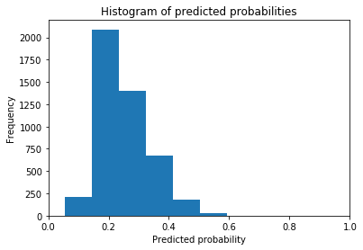

```
ROC curve for classifier: LR
```

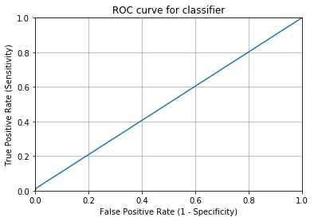

```
AUC for classifier: LR  =  0.6130037967934151

XXXXXXXXXXXXXXXXXXXXXXXXXXXXXXXXXXXXXXXXXXXXXXXXXXXXXXXXXXXXXXXXXXXXXXXXXXXXXXXXXXXXXXXX

Estimate Model Accuracy: mean (std)
LDA: 0.748275 (0.003000)

Prediction: LDA
Accuracy Score: 0.7592067988668555

Confusion Matrix:
 [[3456   27]
 [1078   28]]


Classification Report:
               precision    recall  f1-score   support

           0       0.76      0.99      0.86      3483
           1       0.51      0.03      0.05      1106

    accuracy                           0.76      4589
   macro avg       0.64      0.51      0.46      4589
weighted avg       0.70      0.76      0.67      4589



Prediction probabilities distribution: LDA
```

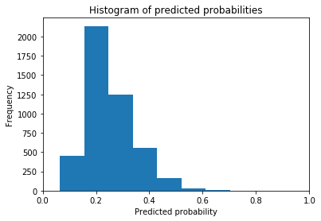

```
ROC curve for classifier: LDA
```

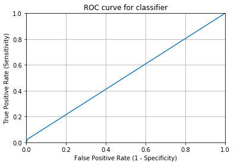

```
AUC for classifier: LDA  =  0.6120910711235508

XXXXXXXXXXXXXXXXXXXXXXXXXXXXXXXXXXXXXXXXXXXXXXXXXXXXXXXXXXXXXXXXXXXXXXXXXXXXXXXXXXXXXXXX

Estimate Model Accuracy: mean (std)
KNN: 0.702579 (0.004318)

Prediction: KNN
Accuracy Score: 0.7193288298104162

Confusion Matrix:
 [[3120  363]
 [ 925  181]]


Classification Report:
               precision    recall  f1-score   support

           0       0.77      0.90      0.83      3483
           1       0.33      0.16      0.22      1106

    accuracy                           0.72      4589
   macro avg       0.55      0.53      0.52      4589
weighted avg       0.67      0.72      0.68      4589



Prediction probabilities distribution: KNN
```

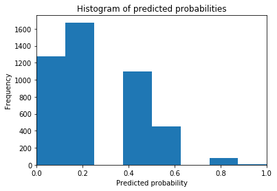

```
ROC curve for classifier: KNN
```

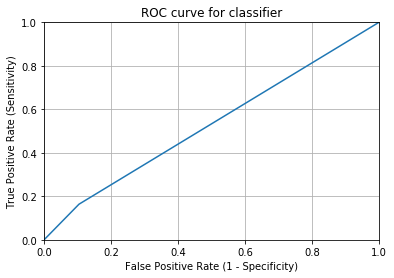

```
AUC for classifier: KNN  =  0.5405916310636161

XXXXXXXXXXXXXXXXXXXXXXXXXXXXXXXXXXXXXXXXXXXXXXXXXXXXXXXXXXXXXXXXXXXXXXXXXXXXXXXXXXXXXXXX

Estimate Model Accuracy: mean (std)
CART: 0.630076 (0.012278)

Prediction: CART
Accuracy Score: 0.6302026585312704

Confusion Matrix:
 [[2556  927]
 [ 770  336]]


Classification Report:
               precision    recall  f1-score   support

           0       0.77      0.73      0.75      3483
           1       0.27      0.30      0.28      1106

    accuracy                           0.63      4589
   macro avg       0.52      0.52      0.52      4589
weighted avg       0.65      0.63      0.64      4589



Prediction probabilities distribution: CART
```

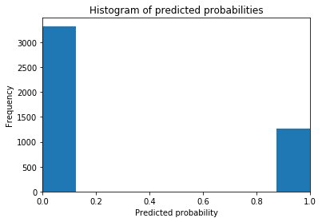

```
ROC curve for classifier: CART
```

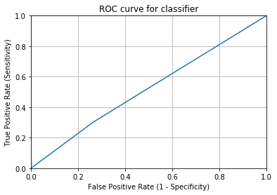

```
AUC for classifier: CART  =  0.5188237987766984

XXXXXXXXXXXXXXXXXXXXXXXXXXXXXXXXXXXXXXXXXXXXXXXXXXXXXXXXXXXXXXXXXXXXXXXXXXXXXXXXXXXXXXXX

Estimate Model Accuracy: mean (std)
RFTree: 0.747185 (0.002265)

Prediction: RFTree
Accuracy Score: 0.7578993244715624

Confusion Matrix:
 [[3422   61]
 [1050   56]]


Classification Report:
               precision    recall  f1-score   support

           0       0.77      0.98      0.86      3483
           1       0.48      0.05      0.09      1106

    accuracy                           0.76      4589
   macro avg       0.62      0.52      0.48      4589
weighted avg       0.70      0.76      0.68      4589



Prediction probabilities distribution: RFTree
```

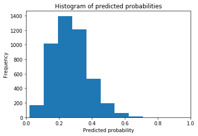

```
ROC curve for classifier: RFTree
```

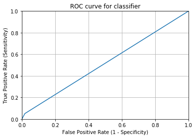

```
AUC for classifier: RFTree  =  0.5863815930541473

XXXXXXXXXXXXXXXXXXXXXXXXXXXXXXXXXXXXXXXXXXXXXXXXXXXXXXXXXXXXXXXXXXXXXXXXXXXXXXXXXXXXXXXX

Estimate Model Accuracy: mean (std)
GrB: 0.749292 (0.003736)

Prediction: GrB
Accuracy Score: 0.758553061669209

Confusion Matrix:
 [[3442   41]
 [1067   39]]


Classification Report:
               precision    recall  f1-score   support

           0       0.76      0.99      0.86      3483
           1       0.49      0.04      0.07      1106

    accuracy                           0.76      4589
   macro avg       0.63      0.51      0.46      4589
weighted avg       0.70      0.76      0.67      4589



Prediction probabilities distribution: GrB
```

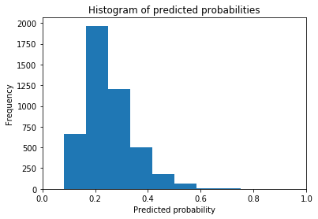

```
ROC curve for classifier: GrB
```

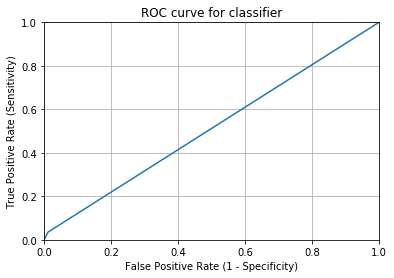

```
AUC for classifier: GrB  =  0.6184737908072222

XXXXXXXXXXXXXXXXXXXXXXXXXXXXXXXXXXXXXXXXXXXXXXXXXXXXXXXXXXXXXXXXXXXXXXXXXXXXXXXXXXXXXXXX

Estimate Model Accuracy: mean (std)
NB: 0.676644 (0.013823)

Prediction: NB
Accuracy Score: 0.6868598823273044

Confusion Matrix:
 [[2811  672]
 [ 765  341]]


Classification Report:
               precision    recall  f1-score   support

           0       0.79      0.81      0.80      3483
           1       0.34      0.31      0.32      1106

    accuracy                           0.69      4589
   macro avg       0.56      0.56      0.56      4589
weighted avg       0.68      0.69      0.68      4589



Prediction probabilities distribution: NB
```

[4 more figures not shown]

```
AUC for classifier: Deep  =  0.5457453121568517

XXXXXXXXXXXXXXXXXXXXXXXXXXXXXXXXXXXXXXXXXXXXXXXXXXXXXXXXXXXXXXXXXXXXXXXXXXXXXXXXXXXXXXXX
```

```python
# Spot Check Algorithms
models = []
models.append(('LR', LogisticRegression(solver='liblinear', multi_class='ovr')))
models.append(('LDA', LinearDiscriminantAnalysis()))
models.append(('KNN', KNeighborsClassifier()))
models.append(('CART', DecisionTreeClassifier()))
models.append(('RFTree', RandomForestClassifier()))
models.append(('GrB', GradientBoostingClassifier()))
models.append(('NB', GaussianNB()))
models.append(('SVM', SVC(gamma='auto')))
models.append(('Deep', MLPClassifier()))

# evaluate each model in turn
results = []
names = []
print()

for name, model in models:
    kfold = StratifiedKFold(n_splits=10, random_state=1, shuffle=True)
    cv_results = cross_val_score(model, X_train, Y_train, cv=kfold, scoring='accuracy')
    results.append(cv_results)
    names.append(name)
    print('Estimate Model Accuracy: mean (std)','\n%s: %f (%f)' % (name, cv_results.mean(), cv_results.std()),'\n')


    # Make predictions on validation dataset

    model.fit(X_train, Y_train)
    predictions = model.predict(X_validation)

    # Evaluate predictions

    print("Prediction:", '%s' % (name))
    print('Accuracy Score:',accuracy_score(Y_validation, predictions))
    print()
    print('Confusion Matrix:\n',confusion_matrix(Y_validation, predictions))
    print('\n')
    print('Classification Report:\n',classification_report(Y_validation, predictions))
    print()


    try:
        # store the predicted probabilities for class 1
        Y_pred_prob = model.predict_proba(X_validation)[:, 1]

    except AttributeError:
        print("An AttributeError has occurred. I can't show the histogram of predicted probabilities, ROC curve for classifier and AUC for the classifier.")

    else:

        # histogram of predicted probabilities

        print()
        print("Prediction probabilities distribution:", '%s' % (name))
        plt.hist(Y_pred_prob, bins=8)
        plt.xlim(0, 1)
        plt.title('Histogram of predicted probabilities')
        plt.xlabel('Predicted probability')
        plt.ylabel('Frequency')
        plt.show()

        # ROC curve for classifier
        # IMPORTANT: first argument is true values, second argument is predicted probabilities
        print()
        print("ROC curve for classifier:", '%s' % (name))
        fpr, tpr, thresholds = metrics.roc_curve(Y_validation, predictions)
        plt.plot(fpr, tpr)
        plt.xlim([0.0, 1.0])
        plt.ylim([0.0, 1.0])
        plt.title('ROC curve for classifier')
        plt.xlabel('False Positive Rate (1 - Specificity)')
        plt.ylabel('True Positive Rate (Sensitivity)')
        plt.grid(True)
        plt.show()

        # IMPORTANT: first argument is true values, second argument is predicted probabilities
        print("AUC for classifier:", '%s' % (name),' = ', metrics.roc_auc_score(Y_validation, Y_pred_prob))


    print()
    print('XXXXXXXXXXXXXXXXXXXXXXXXXXXXXXXXXXXXXXXXXXXXXXXXXXXXXXXXXXXXXXXXXXXXXXXXXXXXXXXXXXXXXXXX','\n')
```

Plot of **the spread and the mean accuracy** of each model.

There is a **population of accuracy** measures for each algorithm because each algorithm was evaluated 10 times (via 10 fold-cross validation).

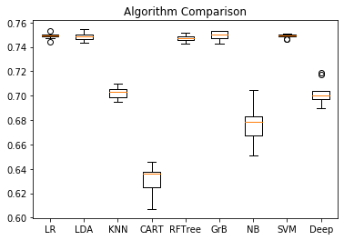

```python
# Compare Algorithms
plt.boxplot(results, labels=names)
plt.title('Algorithm Comparison')
plt.show()
```

### 6.1.b Create a Validation Dataset with Robust Scaled Data

```python
# Split-out validation dataset

X = donor_dataset_scaled_robust.drop('TARGET_B',axis=1)
y = donor_dataset_scaled_robust['TARGET_B']
X_train, X_validation, Y_train, Y_validation = train_test_split(X, y, test_size=0.25, random_state=1)
```

```python
print ('All Data: ', X.size)
print ('Train Size: ', X_train.size,'=', X_train.size/ X.size*100,'%')
print ('Test Size: ', X_validation.size, '=', X_validation.size/X.size*100,'%')
```

```
All Data:  789222
Train Size:  591895 = 74.99727579819113 %
Test Size:  197327 = 25.002724201808867 %
```